# Harvard Data Science Capstone Project

Evaluating the Operational and Equity Impacts of Providence Transit Center Relocation

Author

Larry Mannings

Published

November 22, 2026

# Executive Summary

The Rhode Island Public Transit Authority (RIPTA) is proposing a public-private partnership to move Providence’s central bus hub out of downtown’s Kennedy Plaza to a new site beside Providence Station at Park Row West and Francis Street (*hereafter referred to as* *Park Row West*). While moving this hub would modernize aging infrastructure and connect buses directly to commuter rail, shifting the system’s anchor to the northern edge of Downcity Providence fundamentally changes how buses—and riders—move through the city.

This study evaluates the operational, financial, and rider-access impacts of that move using 12 months of actual RIPTA bus-tracking records (*covering more than 335,000 inbound trips*), published bus schedules, U.S. Census data, and local elevation maps. Combining historical trend analysis with machine learning, this study measures how extended routes add to everyday travel times—and uncovers hidden **rush-hour tipping points**—where crowded streets, tight turns, and back-to-back buses suddenly cause delays to snowball across the network.

## Key Findings

- **Higher Operating Costs and Fleet Strain:** Providence’s downtown transit network already runs close to capacity, where rush-hour traffic, narrow historic streets, and back-to-back bus arrivals create daily bottlenecks. Moving the hub north to Park Row West forces most incoming buses—especially from the East, South, and West—to push even deeper through downtown gridlock. Even after accounting for shorter trips on select Northern routes, the move adds a net **2,336 hours of bus service per year** (*about **6.4 hours per day***). Maintaining current schedules without cutting service would require **2 to 3 additional peak buses** and impose a **net annual operating cost increase of $394,279**—spending nearly $400,000 a year simply to absorb longer routes with no gain in service frequency or coverage.
- **A Universal 13.4-Minute Transfer Penalty:** Closing Kennedy Plaza opens a third-of-a-mile (*1,820-foot*) uphill gap between the downtown workplaces and the new bus hub. Whether commuters walk the hill or wait for a connector shuttle, bridging that gap adds an average of **nearly 13.5 minutes** each way for riders heading to or from downtown.
- **A Geographic Divide with Heavy Practical Equity Costs:** Rather than isolating a single demographic group, the new hub’s location creates a stark geographic divide: select Northern routes gain shorter trips and cost savings, while **Eastern, Southern, and Western corridors** absorb compounding delays. Neighborhoods with high concentrations of low-income, elderly, or transit-dependent residents are served by **19 of the 30 delayed bus corridors** entering downtown. Even though the 13.4-minute transfer penalty affects all displaced riders broadly, it falls hardest in practice on transit-dependent, elderly, and mobility-challenged riders who cannot switch to private vehicles or walk the uphill grade—undermining the *Transit Forward RI 2040* Master Plan’s goal of expanding reliable transit for low-income, minority, and older residents.

## Key Recommendations

- **Adopt a Split-Hub and Cross-Town Strategy:** Rather than forcing every bus to a single northern hub, RIPTA should terminate Northern routes (*such as Routes 50, 55, 56, and 57*) at Park Row West to capture their genuine time and cost savings. Eastern, Southern, and Western routes should remain anchored at Kennedy Plaza or be paired into continuous cross-town lines (*such as Routes 1 and 92*) so riders keep direct Downcity access without triggering steep operating deficits.
- **Target Rush-Hour Bottlenecks:** Install peak-hour **Transit Signal Priority** (*smart traffic lights that hold green lights for approaching buses*) and peak-period bus lanes along Memorial Boulevard and Francis Street, and evaluate direct transit bypasses for high-frequency Southern and Eastern lines (*e.g., Routes 1, 20, 22, 72, and 92*) to eliminate slow downtown looping.
- **Guarantee Frequent, Accessible Shuttle Service:** If a full relocation to Park Row West moves forward, RIPTA should mandate a dedicated, zero-fare shuttle running every **5 minutes or less** during peak and off-peak hours—paired with weather-protected, curb-height (‘*level-boarding*’) stops for wheelchairs and walkers—to reduce the 13.4-minute transfer penalty for seniors and mobility-challenged riders.
- **Test and Measure Before Finalizing:** To eliminate data blind spots and advance future transit equity models, equip buses with **Automated Passenger Counters** (*doorway sensors that log exact boardings at every stop*) to measure exact transfer volumes rather than relying on estimates. Additionally, the agency should run live peak-hour pilot buses along Eastern, Southern, and Western corridors to verify modeled delays on the street before locking in a final hub design.

# 1 Introduction

The Rhode Island Public Transit Authority (RIPTA) and its private development consortium, Next Wave Rhode Island Partners, are moving forward with plans to replace Providence’s central bus hub with a modern indoor terminal. Since 1990, Kennedy Plaza (KP) has anchored Rhode Island’s statewide bus network. Project planners argue, however, that the plaza has outgrown its footprint—citing cramped, exposed bus curbs, crowded sidewalks shared with general downtown foot traffic, and surrounding street congestion. Following an initial evaluation of candidate locations across downtown, project planners narrowed their focus to parcels adjacent to Providence Train Station (*see Fig. 1*).

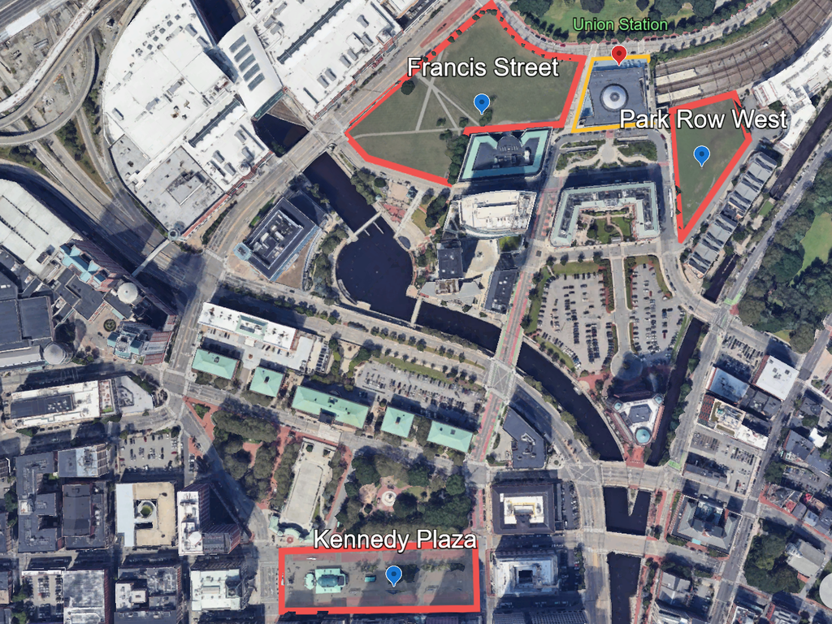

Figure 1: Aerial view of existing (Kennedy Plaza) and proposed (Park Row West/Francis Street) transit centers.

In RIPTA’s initial screening of seven candidate sites, Park Row West scored the highest across 10 planning criteria (Table 1). Strong public interest in connecting buses directly to Amtrak and MBTA commuter trains at Union Station then prompted planners to add an adjacent parcel on Francis Street[^1]—giving buses enough room to turn and circulate around the rail station.

Table 1: Providence Transit Center Site Feasibility Matrix. *Source:* Adapted from Rhode Island Public Transit Authority (RIPTA), *Providence Transit Center Joint Development Project Task 2, Part I – Site Evaluations & Commercial Feasibility, 2025.*

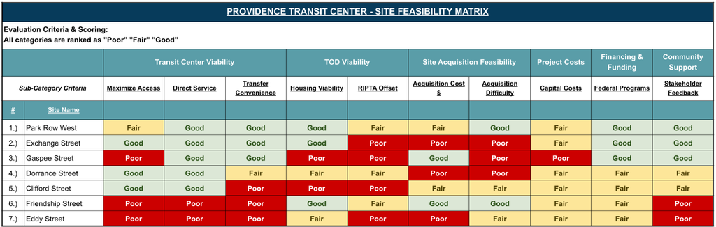

Still, moving the hub away from Kennedy Plaza has sparked fierce pushback from riders, city councilors, and state lawmakers.[^2] While critics agree that linking the buses directly to train service is appealing, they point to four major drawbacks:

**Transit Center Viability:** Kennedy Plaza’s infrastructure is currently built around the flow of traffic, with Providence’s natural road arteries funneling most bus lines towards Kennedy Plaza. It is within a few blocks of City Hall, post office, banks, the public library, universities, and other places people commonly travel to.

**Fiscal Priorities:** Critics note that renovating Kennedy Plaza would cost a fraction of the hundreds of millions required to build a brand-new terminal. Furthermore, opponents of the plan point out that RIPTA has been severely underfunded, facing a “fiscal cliff” that threatens imminent route and service cuts. They argue that Kennedy Plaza already serves as transit-oriented infrastructure and that renovating the site to address Rhode Island’s Transit Master Plan[^3] would represent the best use of funds.

**Transfer Burdens:** Planning reports, public hearings, a Providence City Council resolution, and pending state bills all warn that moving the central bus hub away from Kennedy Plaza would disrupt established transit routes, increase trip times, and hinder overall accessibility by forcing extra transfers for daily commuters.

**Public Process and Real Estate Interests:** Many riders expressed frustration during public outreach sessions that Kennedy Plaza was intentionally omitted as a choice on survey ballots. Some advocates argue that the drive to relocate the transit hub away from Kennedy Plaza is motivated by private real estate interests seeking to clear bus commuters out of the downcity civic community rather than improving transit equity.

# 2 Problem Definition

This study tests the Park Row West proposal in three steps. First, we analyze historical bus records to measure where and why routes already run late heading into Kennedy Plaza today. Second, we map the exact street detours required to reach Park Row West to calculate added driving time, extra buses needed, and annual budget costs. Finally, we simulate the uphill commute across the gap between the two hubs to see whether the move places an unfair burden on transit-dependent, elderly, and mobility-challenged neighborhoods.

## 2.1 Key Questions

1. *What causes bus delays in downtown Providence today, and how will extending routes to Park Row West affect on-time reliability and operating costs?*
2. *Does moving the hub away from Kennedy Plaza create an inequitable burden (‘disparate impact’) that hits low-income, senior, and mobility-challenged riders hardest?*

## 2.2 Data Sources & Ingestion Framework

### 2.2.1 Ideal Datasets

To test how real passengers will be affected, we started with RIPTA’s official schedules (*published in the industry-standard General Transit Feed Specification* [^4] *(GTFS) format*) and digitally reconstructed the route map to terminate at Park Row West.[^5] Because published schedules only reflect ideal plans on paper, we paired them with a full year of RIPTA’s real-world GPS dispatch logs—recording the exact second buses actually arrived at stops across the city. Finally, we linked those routes to U.S. Census neighborhood data and RIPTA’s rider surveys to distinguish transit-dependent communities from wealthier ‘non-vulnerable’ commuters.[^6]

### 2.2.2 Primary Data Summary

#### 2.2.2.1 RIPTA CAD/AVL Historical Archive

Published timetables estimate intermediate stop times mathematically, while public live-tracking feeds (*GTFS-Realtime*) restrict how much historical data can be downloaded. To build an exact four-season record, we obtained a full 12-month archive of internal Computer-Aided Dispatch and Automatic Vehicle Location (*CAD/AVL*) logs via a Rhode Island Access to Public Records Act (APRA)[^7] request. These records log *scheduled vs. actual* bus arrivals to the second alongside precise GPS coordinates—allowing us to measure corridor delays just before buses hit downtown hub congestion.

#### 2.2.2.2 RIPTA Kennedy Plaza Transfer Data & Passenger Counts

Next Wave Rhode Island Partners surveyed 4,438 people during public outreach, recording home ZIP codes and trip purposes. However, the survey did not record which specific bus routes respondents rode, and ZIP codes are too broad to tie responses to individual lines. Moreover, because the survey was distributed only online and at public meetings—and included roughly 15% non-riders and infrequent riders—it does not represent daily bus commuters as a whole. Because answering Question II requires knowing how many incoming passengers end their trip within a quarter-mile walk of Kennedy Plaza, we combine this survey baseline with route-level ridership in Section 3.5.

#### 2.2.2.3 U.S. Census Bureau Databases

U.S. Census Bureau block-group demographic data was extracted via the American Community Survey (ACS) 5-Year estimates. This data—specifically tracking median household income, race and ethnicity, zero-vehicle households, residents with walking disabilities, and senior populations—is used to define the study’s Transit-Dependent and Mobility-Challenged vulnerability tiers.

#### 2.2.2.4 RIGIS Digital Elevation Models (DEM) & Spatial Layers

Elevation datasets from the Rhode Island Geographic Information System (RIGIS) were paired with street and parcel boundaries to map quarter-mile walking zones, street steepness, and effort-weighted walking speeds.

#### 2.2.2.5 Data & Analytical Environment

Full schema specifications for the RIPTA GTFS feed and an inventory of the core R packages used in this analysis are documented in the **Technical Appendix**.

# 3 Exploratory Data Analysis (EDA): Mapping Baseline Operations & Equity

To evaluate the spatial, operational, and social equity impacts of relocating Providence’s central transit hub from Kennedy Plaza to Park Row West, we constructed a multi-stream exploratory data analysis (EDA) pipeline (Fig. 2). This analytical architecture combines distinct data sources—including General Transit Feed Specification (GTFS) schedule feeds, historical Computer-Aided Dispatch and Automatic Vehicle Location (CAD/AVL) event logs, U.S. Census Bureau American Community Survey (ACS) 5-Year estimates, Rhode Island Geographic Information System (RIGIS) digital elevation models, and public outreach survey responses—into five core processing modules:

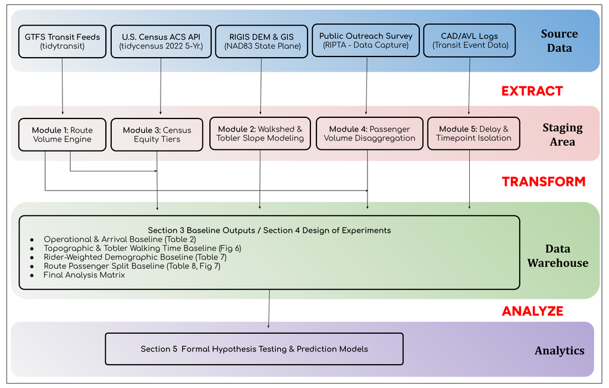

Figure 2: Exploratory Data Analysis (EDA) Data Pipeline Architecture.

## 3.1 Transit Operations Baseline (RIPTA GTFS Network Profile)

Answering *Key Question I* requires measuring how route extension distances add driving time—and how those lost minutes translate into extra operating costs and fleet vehicles. To establish a clean baseline before modeling the move, we built a data pipeline evaluating all high-frequency bus routes funneling into Downcity Providence through Kennedy Plaza during peak daytime operating hours. Isolating inbound trips allows us to measure arrival frequencies by street corridor and group routes by their cardinal approach direction—North, South, East, or West (Fig. 3).

[figure not shown]

Figure 3: Kennedy Plaza High Frequency Bus Routes and Transit Corridor. Note. *Adapted from Rhode Island Public Transit Authority (RIPTA)*, Providence Transit Map & Pocket Guide (Dec. 2021).

### 3.1.1 Network Scope & High-Frequency Coverage

To evaluate the operational and equity impacts where the transit demand is most concentrated, we focus this study on the primary bus routes serving Kennedy Plaza with peak frequencies of *at least two trips per hour (headways* $\le$ *30 minutes)*. This filters out low-frequency rural coverage routes and long-distance express commuter runs, isolating the core urban transit network to be representative of daily boardings, driver service hours, and bus-to-bus transfers.

We ingested RIPTA’s `stops.txt` and `stop_times.txt` static files to isolate inbound trips serving Kennedy Plaza during daytime business hours (*08:00 AM–06:00 PM*). Linking those trips to `trips.txt` route metadata, we calculated each line’s hourly arrival frequency and average wait time between buses (‘*headway*’), filtering out routes with headways longer than 30 minutes. Table 2 summarizes the 10 highest-frequency corridors entering Kennedy Plaza.

```r
csv_path <- "../data/scratch/route_kp_frequency.csv"

 route_kp_frequency <- read_csv(csv_path, show_col_types = FALSE)

# Automatically TRUE for PDF renders, FALSE for HTML and interactive work
is_pdf <- isTRUE(knitr::pandoc_to("latex")) || isTRUE(knitr::pandoc_to("pdf")) || knitr::is_latex_output()

t <- route_kp_frequency |>
  arrange(desc(trip_freq)) |>
  slice(1:10) |>
  mutate(trip_freq = sprintf("%.2f", trip_freq)) |> #format to 2 decimal
  #places
  kable(
    format = if (is_pdf) "latex" else "html",
    booktabs = is_pdf,
    escape = FALSE,
    col.names = c("Route ID", "Route Name", "Approach Direction",
                  "Total Arrivals", "First Arrival", "Last Arrival",
                  "Headway", "Frequency"),
    align = "c"
  ) |>
    add_header_above(c("High-Frequency Routes into Kennedy Plaza [Top 10]"=8),
                   bold = TRUE,
                   background = "#4682B4", # Hex for steelblue
                   color = "#ADD8E6"       # Hex for lightblue
                   )

if (is_pdf) {
  t |> kable_styling(latex_options = c("striped", "hold_position", "scale_down"))
} else {
  t |> kable_styling(bootstrap_options = c("striped", "bordered", "hover", "condensed"), full_width = FALSE)
}
```

Table 2: RIPTA High-Frequency Routes Inbound to Kennedy Plaza (Top 10). *Note:* Data sourced from the Rhode Island Public Transit Authority (RIPTA), General Transit Feed Specification (GTFS) data feed (https://www.ripta.com/RIPTA-GTFS.zip).

| High-Frequency Routes into Kennedy Plaza [Top 10] Route ID | High-Frequency Routes into Kennedy Plaza [Top 10] Route Name | High-Frequency Routes into Kennedy Plaza [Top 10] Approach Direction | High-Frequency Routes into Kennedy Plaza [Top 10] Total Arrivals | High-Frequency Routes into Kennedy Plaza [Top 10] First Arrival | High-Frequency Routes into Kennedy Plaza [Top 10] Last Arrival | High-Frequency Routes into Kennedy Plaza [Top 10] Headway | High-Frequency Routes into Kennedy Plaza [Top 10] Frequency |
| --- | --- | --- | --- | --- | --- | --- | --- |
| 11 | Broad/North Main | East | 104 | 08:05:00 | 17:59:00 | 5.8 | 10.34 |
| 11 | Broad/North Main | West | 104 | 08:05:00 | 17:59:00 | 5.8 | 10.34 |
| 31 | Cranston St | North | 68 | 08:03:00 | 17:58:00 | 8.9 | 6.74 |
| 56 | Chalkstone Ave | North | 67 | 08:06:00 | 17:57:00 | 9.0 | 6.67 |
| 20 | Elmwood Ave/Airport | South | 62 | 08:13:00 | 17:58:00 | 9.6 | 6.25 |
| 1 | Eddy St/Hope St/Benefit St | South | 60 | 08:10:00 | 17:58:00 | 10.0 | 6.00 |
| 1 | Eddy St/Hope St/Benefit St | East | 59 | 08:10:00 | 17:58:00 | 10.1 | 5.94 |
| 50 | Douglas Ave | North | 57 | 08:13:00 | 17:58:00 | 10.4 | 5.77 |
| 72 | Weeden St (Central Falls) | North | 57 | 08:00:00 | 18:00:00 | 10.7 | 5.61 |
| 92 | East Side/Federal Hill/RI College | East | 50 | 08:00:00 | 17:46:00 | 12.0 | 5.00 |

Fig. 4 summarizes inbound routes to Kennedy Plaza with peak headways 30 minutes or less (*at least 2 buses per hour*). These routes cover all four cardinal approach directions, providing a comprehensive baseline for transit analysis.

Notably, several primary routes appear in multiple approach corridors. Specifically, Route 11, Route 1, and Route 92 appear twice in Fig. 4. This occurs because RIPTA uses *through-running* routes; instead of terminating at Kennedy Plaza, these routes connect distinct origin terminals and pass through the hub as a mid-route stop. To accurately capture localized traffic congestion and arrival frequencies, our GTFS pipeline evaluates each of these route branches independently based on its specific inbound approach.

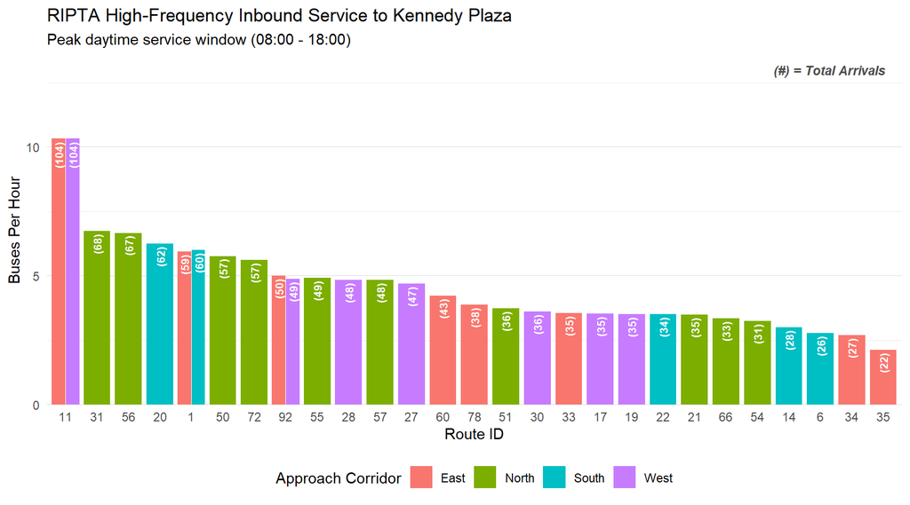

Figure 4: RIPTA High-Frequency Inbound Service to Kennedy Plaza.

```r
route_kp_frequency |>
  ggplot(aes(x = reorder(route_id, -trip_freq),
             y = trip_freq,
             fill = approach_direction)) +
  geom_col(
    width = 0.85,
    position = position_dodge(width = 0.9)
  ) +
  geom_text(
    aes(label = paste0("(", total_arrivals, ")")),
    position = position_dodge(width = 0.9),
    angle = 90,
    hjust = 1.15,          # Anchors inside the top edge of the column
    vjust = 0.5,           # Centered across the column thickness
    color = "white",
    fontface = "bold",
    size = 2.8             # Scaled to fit comfortably within the bar width
  ) +
# Annotation placed in upper right whitespace

  annotate(
    "text",
    x = Inf,
    y = Inf,
    label = "(#) = Total Arrivals",
    hjust = 1.15,
    vjust = 2.0,
    fontface = "bold.italic",
    size = 3.3,
    color = "grey30"
  ) +
  scale_y_continuous(
    limits = c(0, max(route_kp_frequency$trip_freq, na.rm = TRUE) * 1.25),
    expand = expansion(mult = c(0, 0.05))
  ) +
  labs(
    title = "RIPTA High-Frequency Inbound Service to Kennedy Plaza",
    subtitle = "Peak daytime service window (08:00 - 18:00)",
    x = "Route ID",
    y = "Buses Per Hour",
    fill = "Approach Corridor"
  ) +
  theme_minimal(base_size = 11) +
  theme(
    panel.grid.major.x = element_blank(),
    legend.position = "bottom"
  )
```

Isolating daytime inbound trips (*08:00 AM–06:00 PM*) on these high-frequency corridors captures 64% of all RIPTA fixed-route lines and 36% of all 24-hour bus arrivals at Kennedy Plaza. Because this high-frequency urban core accounts for a lion’s share of active passenger service hours (‘*Vehicle Revenue Hours*’) and daily boardings, it pinpoints where route extensions will drive up operating costs fastest.

## 3.2 Spatial Access and Topography

Evaluating operating costs, walking access, and transfers requires digitally modifying RIPTA’s current street network to test the proposed hub. In this section, we link state geographic map layers (*RIGIS*) with RIPTA’s route map and add simulated bus berths at Park Row West.

### 3.2.1 GTFS Network Modification & Park Row West Hub Geo-Coding

#### 3.2.1.1 Adding Hypothetical Stops

Assuming the Park Row West parcel will serve as the primary pedestrian concourse for the relocated hub, we selected a coordinate corresponding to a point directly on the Park Row West roadway between Stillman Street and Exchange Terrace, placing the hypothetical transit hub bus berths alongside the Providence Station (41°49’46.40”N 71°24’49.41”W). To simulate this in the GTFS pipeline, we generated new stop entries in `stops.txt` to represent the Park Row West bus berths (e.g. `stop_id = "PRW_FS_01"`, `stop_name = "Park Row West Transit Center"`, `stop_lat = 41.8296`, `stop_lon = -71.4136`).

#### 3.2.1.2 Route Realignment Mapping

We used the `sf` (*Simple Features*) package to map the physical street network path required for inbound routes to navigate between their existing Kennedy Plaza alignment and the new Park Row West terminal. By combining these geometries with the `osrm` routing engine, we simulated exact driving distances and travel paths for both baseline and relocated hub scenarios.

### 3.2.2 Comparative 1/4-Mile Walkshed Buffer Analysis

#### 3.2.2.1 Projection Alignment

Because standard GPS coordinates (*latitude/longitude*) distort distance measurements depending on their distance from the equator, we re-projected our spatial data into the local RIGIS coordinate reference system (*Rhode Island State Plane*) using the `st_transform()` function in the `sf` package. This ensures that all spatial distances and walking buffers are calculated accurately in linear feet.

#### 3.2.2.2 Walking Buffer Generation

To evaluate spatial accessibility across both terminal locations, 1/4-mile pedestrian walkshed buffers were established around KP and Park Row West. Utilizing the `osrm` package, we mapped quarter-mile **street-network isochrones**—polygons tracing the exact area reachable within a 5-minute walk along real sidewalks at 3.0 mph. As shown in Fig. 5, this mapping reveals minimal overlap between the two walksheds, separating the Downcity commercial core (*Providence City Hall and the Financial District*) from the northern institutional and rail cluster (*Providence Station, the RI State House, and Providence Place Mall*). It also quantifies the ~**1,820-foot (0.34-mile) relocation extension**, representing an additional commute gap that transit riders must navigate when traveling between Kennedy Plaza and the proposed northern hub.

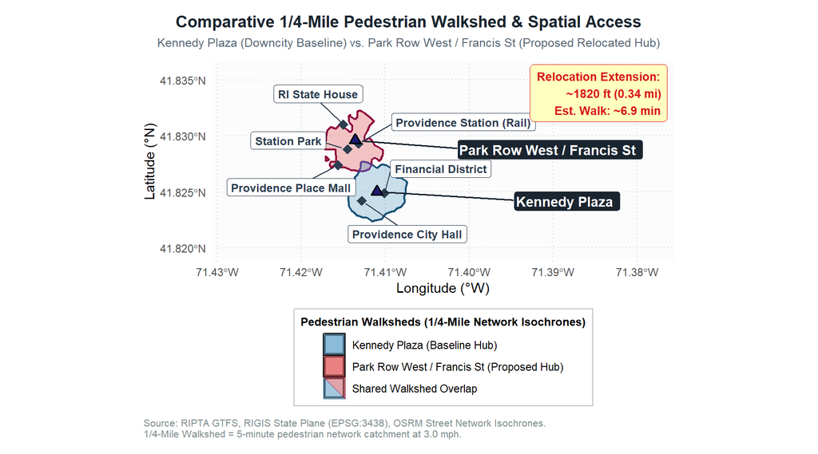

Figure 5: Providence Downcity with Walkshed Overlay.

```r
library(sf)
library(tidycensus)
script_path <- "../scripts/eda/eda_02_network_topography.R"
cache_path  <- "../data/objects/network_topography_cache.rds"

# Only re-run the source script if it was modified or cache doesn't exist
if (!file.exists(cache_path) || file.mtime(script_path) > file.mtime(cache_path)) {
  source(script_path)
} else {
  # Load the bundle back into your environment
    loaded_bundle <- readRDS(cache_path)
    hubs_ri <- loaded_bundle$hubs_ri
    landmarks_ri <- loaded_bundle$landmarks_ri
    walkshed_buffers         <- loaded_bundle$walkshed_buffers
    walkshed_overlap         <- loaded_bundle$walkshed_overlap
    path_line_ri             <- loaded_bundle$path_line_ri
    extension_distance_feet  <- loaded_bundle$extension_distance_feet
    extension_distance_miles <- loaded_bundle$extension_distance_miles
    est_walk_time_min        <- loaded_bundle$est_walk_time_min
}

# Step 2: Custom Diagonal Key Glyph for Shared Walkshed Overlap Legend Icon
draw_key_diagonal_overlap <- function(data, params, size) {
  if (!is.null(data$fill) && (data$fill == "#91bfdb" || data$fill == "Shared Walkshed Overlap")) {
    grid::grobTree(
      grid::polygonGrob(
        x = c(0, 0, 1),
        y = c(0, 1, 0),
        gp = grid::gpar(
          fill = scales::alpha("#2b83ba", 0.35),
          col  = "#1a5276",
          lwd  = 0.8
        )
      ),
      grid::polygonGrob(
        x = c(0, 1, 1),
        y = c(1, 1, 0),
        gp = grid::gpar(
          fill = scales::alpha("#d7191c", 0.35),
          col  = "#900c3f",
          lwd  = 0.8
        )
      )
    )
  } else {
    fill_col  <- if (is.null(data$fill)) "white" else data$fill
    alpha_val <- if (is.null(data$alpha)) 0.5 else data$alpha
    grid::rectGrob(gp = grid::gpar(fill = scales::alpha(fill_col, alpha_val)))
  }
}

# Step 4: Generate Comparative Isochrone & Walkshed Map
fig_walkshed_map <- ggplot() +

  # 1. Individual 1/4-Mile Walkshed Buffers (KP vs. Park Row West)
  geom_sf(
    data = walkshed_buffers,
    aes(fill = hub_name),
    color = c("#1a5276", "#900c3f"),
    linewidth = 0.8,
    alpha = 0.25,
    show.legend = TRUE
  ) +

  # 2. Shared Walkshed Overlap Zone (Uses Custom Diagonal Legend Key)
  geom_sf(
    data = walkshed_overlap,
    aes(fill = zone_name),
    color = "#5e3c99",
    linewidth = 0.6,
    alpha = 0.40,
    key_glyph = draw_key_diagonal_overlap,
    show.legend = TRUE
  ) +

  # 3. Landmark Locations (Retail, Civic, Transit Anchors)
  geom_sf(
    data = landmarks_ri,
    color = "#2c3e50",
    shape = 18,
    size = 3.5,
    show.legend = FALSE
  ) +

  # 4. Primary Transit Hub Locations (Updated to Triangle Shape)
  geom_sf(
    data = hubs_ri,
    shape = 24,
    fill = "#191970",
    color = "#000000",
    size = 2.5,
    stroke = 1.0,
    show.legend = FALSE
  ) +

  # 5. Repelled Labels for Civic & Commercial Landmarks
  geom_label_repel(
    data = landmarks_ri,
    aes(geometry = geometry, label = landmark_name),
    stat = "sf_coordinates",
    size = 3.2,
    fontface = "bold",
    fill = "#ffffff",
    color = "#2c3e50",
    nudge_x = -100,
    nudge_y = 200,
    box.padding = unit(0.8, "lines"),
    point.padding = unit(0.6, "lines"),
    force = 15,
    min.segment.length = unit(0, "lines"),
    segment.color = "#2c3e50",
    segment.size = 0.5,
    show.legend = FALSE
  ) +

  # 6. Hub Labels Extended Far Right
  geom_label_repel(
    data = hubs_ri,
    aes(geometry = geometry, label = short_name),
    stat = "sf_coordinates",
    size = 3.8,
    fontface = "bold",
    fill = "#1a252f",
    color = "#ffffff",
    nudge_x = 5000,
    nudge_y = -300,
    direction = "y",
    hjust = 0,
    box.padding = unit(0.8, "lines"),
    point.padding = unit(0.6, "lines"),
    force = 10,
    min.segment.length = unit(0, "lines"),
    segment.color = "#1a252f",
    segment.size = 0.7,
    show.legend = FALSE
  ) +

  # 7. Relocation Extension Callout Box
  annotate(
    "label",
    x = Inf,
    y = Inf,
    label = sprintf(
      "Relocation Extension:\n~%.0f ft (%.2f mi)\nEst. Walk: ~%.1f min",
      extension_distance_feet, extension_distance_miles, est_walk_time_min
    ),
    fill = "#ffffbf",
    color = "#d7191c",
    size = 3.3,
    fontface = "bold",
    label.padding = unit(0.5, "lines"),
    label.r = unit(0.3, "lines"),
    hjust = 1.05,
    vjust = 1.05
  ) +

  # 8. Fill Legend Scale
  scale_fill_manual(
    name = "Pedestrian Walksheds (1/4-Mile Network Isochrones)",
    values = c(
      "Kennedy Plaza (Baseline Hub)" = "#2b83ba",
      "Park Row West / Francis St (Proposed Hub)" = "#d7191c",
      "Shared Walkshed Overlap" = "#91bfdb"
    ),
    breaks = c(
      "Kennedy Plaza (Baseline Hub)",
      "Park Row West / Francis St (Proposed Hub)",
      "Shared Walkshed Overlap"
    )
  ) +

  # 9. Coordinate Bounds
  coord_sf(
    crs = st_crs(3438),
    datum = st_crs(4326),
    xlim = c(347000, 362000),
    ylim = c(268000, 274500),
    expand = FALSE,
    clip = "off"
  ) +

  # 10. Plot Labels
  labs(
    title = "Comparative 1/4-Mile Pedestrian Walkshed & Spatial Access",
    subtitle = "Kennedy Plaza (Downcity Baseline) vs. Park Row West / Francis St (Proposed Relocated Hub)",
    caption = "Source: RIPTA GTFS, RIGIS State Plane (EPSG:3438), OSRM Street Network Isochrones.\n1/4-Mile Walkshed = 5-minute pedestrian network catchment at 3.0 mph.",
    x = "Longitude (°W)",
    y = "Latitude (°N)"
  ) +

  # 11. Legend & Theme Settings
  guides(fill = guide_legend(ncol = 1, title.position = "top", title.hjust = 0.5)) +
  theme_minimal(base_size = 11) +
  theme(
    panel.grid.major = element_line(color = "#e0e0e0", linetype = "dotted"),
    panel.grid.minor = element_blank(),
    plot.title = element_text(face = "bold", size = 13, color = "#1a252f", hjust = 0.5),
    plot.subtitle = element_text(size = 9.5, color = "#566573", hjust = 0.5, margin = margin(b = 10)),
    plot.title.position = "plot",
    plot.caption.position = "plot",
    plot.caption = element_text(size = 8, color = "#7f8c8d", hjust = 0, margin = margin(t = 10)),
    plot.margin = margin(t = 12, r = 25, b = 12, l = 25, unit = "pt"),
    legend.position = "bottom",
    legend.direction = "vertical",
    legend.title = element_text(face = "bold", size = 9),
    legend.text = element_text(size = 8.5),
    legend.key.size = unit(1.2, "lines"),
    legend.background = element_rect(fill = alpha("white", 0.9), color = "#bdc3c7"),
    panel.background = element_rect(fill = "#fcfcfc", color = NA)
  ) +

  # 12. Legend 2: Map Symbols
  scale_shape_manual(
    name = "Map Feature Symbols",
    values = c(
      "Transit Hub Terminal" = 24,
      "Civic / Retail Landmark" = 18
    )
  ) +
  scale_color_manual(
    name = "Map Feature Symbols",
    values = c(
      "Transit Hub Terminal" = "#000000",
      "Civic / Retail Landmark" = "#2c3e50"
    )
  )

# Bundle and save variables for future use
my_saved_args <- list(
    hubs_ri = hubs_ri,
    landmarks_ri = landmarks_ri,
    walkshed_buffers      = walkshed_buffers,
    walkshed_overlap      = walkshed_overlap,
    path_line_ri          = path_line_ri,
    extension_distance_feet  = extension_distance_feet,
    extension_distance_miles = extension_distance_miles,
    est_walk_time_min     = est_walk_time_min
)

saveRDS(my_saved_args, file = cache_path)

# Display plot
fig_walkshed_map
```

#### 3.2.2.3 Destination Overlap

We overlay these walking zones onto U.S. Census neighborhood maps to measure how shifting the hub changes rider access to jobs and services. Refer to Section 3.3 for more details.

### 3.2.3 Terrain Slope Modeling & Pedestrian Impacts

A core goal of Rhode Island’s *Transit Forward RI 2040* Master Plan is to provide transit services that “help people live independently as they age.” Evaluating the physical terrain between the two hubs directly supports determining the effectiveness of this state mandate. While the street-network analysis establishes the 0.34-mile (*1,820-foot*) horizontal distance between Downcity Providence and Park Row West, answering *Key Question II* requires linking elevation profiles to demographic equity indicators. In the modeling phase, RIGIS Digital Elevation Model (DEM) rasters are paired with a terrain-based walking speed formula to measure the corridor’s elevation grade and compute effort-weighted travel times for standard and mobility-challenged transit riders. These slope-adjusted penalties establish whether vulnerable populations bear a disproportionate physical burden under the relocated hub scenario.

#### 3.2.3.1 RIGIS DEM Integration

High-resolution elevation data was imported from the RIGIS DEM raster using the `rast()` function in the `terra` package. Projected in Rhode Island State Plane coordinates (EPSG:3438), this continuous surface provides ground elevation measurements in feet across downtown Providence. Aligning these raster values with the pedestrian street network enables exact calculation of terrain grade between Kennedy Plaza and the proposed Park Row West hub.

#### 3.2.3.2 Methodology & Industry Sources for Walking Speeds:

- **Transit Capacity and Quality of Service Manual (TCQSM)**[^8]:
  - **Standard Pedestrian Baseline: 3.0 - 3.1 mph** (*264-275 ft/min or 5.0 km/h*)
  - **Mobility-Challenged / Senior Baseline: 2.0 mph** (*176 ft/min or 3.2 km/h*)
- **Federal Highway Administration (FHWA) Pedestrian Facilities Guidance**[^9]:
  - Specifies accessible design walking speeds between **2.0 and 2.8 ft/s (1.36-1.91 mph)** for pedestrian routes serving high proportions of seniors or persons with ambulatory disabilities.

#### 3.2.3.3 Slope Gradient Calculation

Extracting raster elevation values along pedestrian walkways connecting Park Row West to Downcity Providence yields the corridor’s average slope gradient $(S)$, defined as the vertical elevation change over horizontal distance (*both measured in feet*):

$$S=\frac{\Delta \text{elevation}}{\text{horizontal distance}}$$

This rise-over-run slope ratio measures steepness along each sidewalk segment (*e.g.,* $S=0.02$ *represents a 2% uphill grade*) and feeds directly into our walking-speed model.

#### 3.2.3.4 Effort-Weighted Walking Penalties

To translate the corridor’s slope gradient $(S)$ into realistic pedestrian travel times, this analysis models *effort-weighted* walking speeds using Tobler’s Hiking Function.[^10] Accounting for terrain resistance quantifies how the grade ascending toward the Capitol building slows pedestrian movement and places a disproportionate burden on older adults and mobility-impaired riders.

- **Standard Walking Velocity:** Tobler’s Hiking Function estimates baseline walking speed $V(S)$ (*in km/h*) as a function of dimensionless terrain slope $S$:

$$V(S)=6\cdot e^{-3.5 \cdot |S+0.05|}$$

- **Mobility-Challenged Scaling Factor** $(\alpha)$**:** To model slower baseline movement for mobility-challenged commuters $(V_{mobility}(S)=\alpha \cdot V(S))$, Tobler’s curve is scaled by the ratio of flat-ground mobility-impaired walking speed (*1.89 mph*) to Tobler’s flat-terrain baseline $(V(0) \approx 5.04\text{ km/h or } 3.13 \text{ mph})$:

$$\alpha=\frac{V_{mobility}(0)}{V_{standard}(0)}=\frac{1.89\text{mph}}{3.13\text{mph}}\approx 0.605$$

Converting Tobler’s velocity $V(S)$ from km/hr into feet per minute $(1\text{ km/h} = 54.68 \text{ ft/min})$ and multiplying by $\alpha=0.605$ establishes the slope-adjusted pace for mobility-challenged riders along each segment of the climb.

#### 3.2.3.5 Elevation Penalties and Walking Times

As illustrated in Fig. 6 (*Panel A*), the 1,820-foot pedestrian path connecting KP to Park Row West initially proceeds across flat terrain before climbing Francis Street toward Capitol Hill. The route reaches 32.5 feet above Mean Sea Level (*MSL*) at the proposed hub, creating a net elevation gain of 22.5 ft. While the average incline gradient is 1.2%, localized slopes along the Francis Street corridor peak at 2.2%, presenting a physical barrier for mobility-challenged transit users.

Cumulative walking times along this extension path are detailed in Fig. 6 (*Panel B*). Crucially, a mobility-challenged rider navigating this incline requires 11.30 minutes to make the trek. Compared to a standard adult walking a flat baseline path (*6.54 minutes*), the relocation imposes a 4.76 minute (*72.8% increase*) travel time penalty.

When connecting RIPTA buses run every 15 minutes, an **11.3-minute uphill walk** consumes three-quarters of a rider’s entire transfer window—turning a routine downtown connection into a major physical barrier for mobility-challenged passengers.

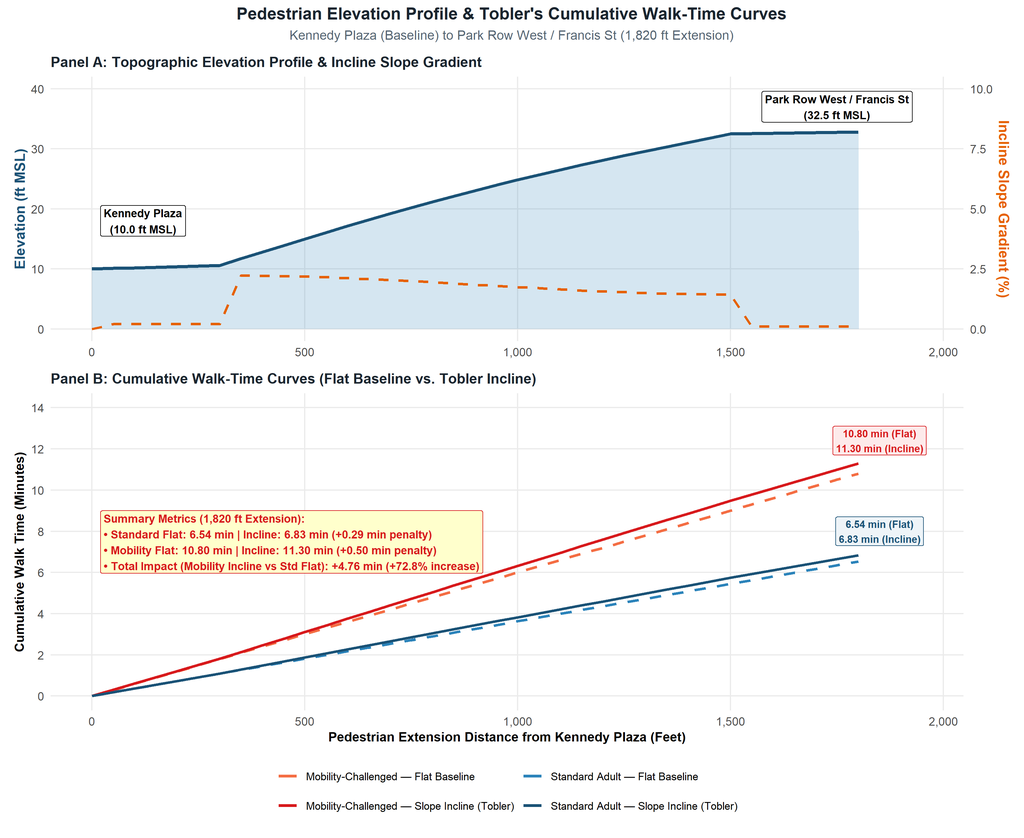

Figure 6: Pedestrian Elevation Profile and Tobler’s Cumulative Walk-Time Curves for the Kennedy Plaza to Park Row West Extension.

```r
library(tidyverse)
library(scales)
library(patchwork)

# 1. Ingest Terrain Slope Summary CSV (../scripts/eda/eda_02_terrain_slope_tobler.R)
elevation_df <- read_csv("../data/scratch/terrain_slope_tobler_summary.csv", show_col_types = FALSE)

# 2. Panel A: Topographic Elevation Profile & Incline Slope Gradient
p_panel_a <- ggplot(elevation_df, aes(x = dist_from_kp_ft)) +
  geom_area(aes(y = elevation_ft), fill = "#2b83ba", alpha = 0.20) +
  geom_line(aes(y = elevation_ft, color = "Elevation (ft MSL)"), linewidth = 1.2) +
  geom_line(aes(y = percent_slope * 4, color = "Incline Slope (%)"), linetype = "dashed", linewidth = 1.0) +
  scale_y_continuous(
    name = "Elevation (ft MSL)",
    limits = c(0, 40),
    sec.axis = sec_axis(~ . / 4, name = "Incline Slope Gradient (%)")
  ) +
  scale_color_manual(
    name = "Profile Metrics",
    values = c("Elevation (ft MSL)" = "#1a5276", "Incline Slope (%)" = "#e66101")
  ) +
  scale_x_continuous(limits = c(0, 1950), labels = comma) +
  annotate("label", x = 120, y = 18, label = "Kennedy Plaza\n(10.0 ft MSL)", size = 3, fontface = "bold", fill = "white") +
  annotate("label", x = 1750, y = 37, label = "Park Row West / Francis St\n(32.5 ft MSL)", size = 3, fontface = "bold", fill = "white") +
  labs(
    title = "Panel A: Topographic Elevation Profile & Incline Slope Gradient",
    x = NULL
  ) +
  theme_minimal(base_size = 11) +
  theme(
    plot.title = element_text(face = "bold", size = 11, color = "#1a252f"),
    axis.title.y.left = element_text(color = "#1a5276", face = "bold"),
    axis.title.y.right = element_text(color = "#e66101", face = "bold"),
    panel.grid.minor = element_blank(),
    legend.position = "none"
  )

# 3. Panel B: Reshape Data & Plot Cumulative Walk-Time Curves
times_long <- elevation_df |>
  select(dist_from_kp_ft, time_flat_std_min, time_incline_std_min, time_flat_mob_min, time_incline_mob_min) |>
  pivot_longer(cols = -dist_from_kp_ft, names_to = "scenario", values_to = "time_min") |>
  mutate(
    group = if_else(str_detect(scenario, "std"), "Standard Adult", "Mobility-Challenged"),
    type  = if_else(str_detect(scenario, "flat"), "Flat Baseline", "Slope Incline (Tobler)"),
    label_full = paste(group, type, sep = " — ")
  )

p_panel_b <- ggplot(times_long, aes(x = dist_from_kp_ft, y = time_min, color = label_full, linetype = type)) +
  geom_line(linewidth = 1.1) +
  scale_color_manual(
    name = "Scenario",
    values = c(
      "Standard Adult — Flat Baseline"               = "#2b83ba",
      "Standard Adult — Slope Incline (Tobler)"      = "#1a5276",
      "Mobility-Challenged — Flat Baseline"          = "#f46d43",
      "Mobility-Challenged — Slope Incline (Tobler)" = "#d7191c"
    )
  ) +
  scale_linetype_manual(values = c("Flat Baseline" = "dashed", "Slope Incline (Tobler)" = "solid")) +
  scale_x_continuous(name = "Pedestrian Extension Distance from Kennedy Plaza (Feet)", limits = c(0, 1950), labels = comma) +
  scale_y_continuous(name = "Cumulative Walk Time (Minutes)", limits = c(0, 14), breaks = seq(0, 14, by = 2)) +
  annotate(
    "label",
    x = 20, y = 9.0,
    label = "Summary Metrics (1,820 ft Extension):\n• Standard Flat: 6.54 min | Incline: 6.83 min (+0.29 min penalty)\n• Mobility Flat: 10.80 min | Incline: 11.30 min (+0.50 min penalty)\n• Total Impact (Mobility Incline vs Std Flat): +4.76 min (+72.8% increase)",
    hjust = 0, vjust = 1, size = 3, fontface = "bold", fill = "#ffffcc", color = "#d7191c"
  ) +
  annotate("label", x = 1850, y = 8.0, label = "6.54 min (Flat)\n6.83 min (Incline)", size = 2.8, fontface = "bold", color = "#1a5276", fill = "#eef4f8") +
  annotate("label", x = 1850, y = 12.4, label = "10.80 min (Flat)\n11.30 min (Incline)", size = 2.8, fontface = "bold", color = "#d7191c", fill = "#fdeaea") +
  labs(
    title = "Panel B: Cumulative Walk-Time Curves (Flat Baseline vs. Tobler Incline)"
  ) +
  theme_minimal(base_size = 11) +
  theme(
    plot.title = element_text(face = "bold", size = 11, color = "#1a252f"),
    axis.title = element_text(face = "bold", size = 10),
    legend.position = "bottom",
    legend.title = element_blank(),
    legend.text = element_text(size = 8.5),
    panel.grid.minor = element_blank()
  )

# 4. Combine Panels with Patchwork
p_panel_a / p_panel_b +
  plot_layout(heights = c(1, 1.2)) +
  plot_annotation(
    title = "Pedestrian Elevation Profile & Tobler's Cumulative Walk-Time Curves",
    subtitle = "Kennedy Plaza (Baseline) to Park Row West / Francis St (1,820 ft Extension)",
    theme = theme(
      plot.title = element_text(face = "bold", size = 13, hjust = 0.5, color = "#1a252f"),
      plot.subtitle = element_text(size = 10, hjust = 0.5, color = "#566573")
    )
  ) +
guides(color = guide_legend(nrow = 2), linetype = "none")
```

## 3.3 Demographic Characterization & Census Data Integration

Relocating a central transit hub fundamentally shifts pedestrian walksheds and transfer times. These physical changes can impose disproportionate burdens on transit-dependent populations, specifically low-income households, racial and ethnic minorities, zero-vehicle families, elderly residents, and individuals with ambulatory (*walking or stair-climbing*) disabilities.

To evaluate the spatial equity of the proposed relocation, we established an empirical baseline of the affected population using the U.S. Census Bureau’s American Community Survey (ACS) 5-Year estimates. We extracted this data at the Census Block Group level—the smallest spatial unit that provides detailed socioeconomic variables.

### 3.3.1 U.S. Census American Community Survey (ACS) Variables

Using Census Reporter[^11] as a reference index, we searched for and identified ACS base tables required to model our target demographics. As outlined in Table 3, these selected variables isolate the core socioeconomic and physical mobility factors necessary to construct our equity framework. Crucially, by extracting specific civilian ambulatory disability and senior variables, we can directly evaluate the *Transit Forward RI 2040* Master Plan’s objective to track and protect transit access for residents aged 65 and older.

```r
manual_pdf_override <- NULL

is_pdf <- if (!is.null(manual_pdf_override)) {
  manual_pdf_override
} else {
  isTRUE(knitr::pandoc_to("latex")) || isTRUE(knitr::pandoc_to("pdf")) || knitr::is_latex_output()
}

acs_table <- tribble(
  ~cat,            ~subj,                        ~acs_table,
  "Disability",    "Sex by Age by Disability Status",   "B18101",
  "Elderly 65+",   "Sex by Age",                        "B01001",
  "Income",        "Median Household Income",           "B19013",
  "Vehicle Access","Tenure by Vehicles Available",      "B25044",
  "Race / Ethnicity","Race",                            "B02001"
) |>
  kable(
    format = if (is_pdf) "latex" else "html",
    booktabs = TRUE,
    escape = TRUE,
    col.names = c("Category", "Subject", "ACS Base Table"),
    align = "c"
  )|>
    add_header_above(c("U.S. Census American Community Survey (ACS) Variables"=3),
                   bold = TRUE,
                   background = "#4682B4", # Hex for steelblue
                   color = "#ADD8E6"       # Hex for lightblue
                   )

if (is_pdf) {
  acs_table |> kable_styling(latex_options = c("striped", "hold_position", "scale_down"))
} else {
  acs_table |> kable_styling(bootstrap_options = c("striped", "bordered", "hover", "condensed"), full_width = FALSE)
}
```

Table 3: U.S. Census Bureau American Community Survey (ACS) 5-Year Estimate base tables used to define neighborhood transit equity.

| U.S. Census American Community Survey (ACS) Variables Category | U.S. Census American Community Survey (ACS) Variables Subject | U.S. Census American Community Survey (ACS) Variables ACS Base Table |
| --- | --- | --- |
| Disability | Sex by Age by Disability Status | B18101 |
| Elderly 65+ | Sex by Age | B01001 |
| Income | Median Household Income | B19013 |
| Vehicle Access | Tenure by Vehicles Available | B25044 |
| Race / Ethnicity | Race | B02001 |

### 3.3.2 Equity Classification & Ingestion Pipeline

Using the selected ACS variables, we established a three-tiered classification framework to evaluate the equity impacts of the hub relocation (see Table 4).

```r
manual_pdf_override <- NULL

is_pdf <- if (!is.null(manual_pdf_override)) {
  manual_pdf_override
} else {
  isTRUE(knitr::pandoc_to("latex")) || isTRUE(knitr::pandoc_to("pdf")) || knitr::is_latex_output()
}

# Format-specific line break tags
break_tag <- if (is_pdf) "\\\\" else "<br>"

# Helper wrapper for LaTeX cells using \makecell so \\ doesn't break table rows
cell_wrap <- function(text) {
  if (is_pdf) paste0("\\makecell[l]{", text, "}") else text
}

# Wrapped criteria definitions
crit_group_1 <- cell_wrap(paste0(
  "Income under City Median,", break_tag,
  "AND Minority pct. over City Avg.", break_tag,
  "OR Zero-Car pct. over City Avg."
))

crit_group_2 <- cell_wrap(paste0(
  "Disabled pct. over City Avg.", break_tag,
  "OR Elderly 65+ over City Avg."
))

non_vuln_criteria <- cell_wrap(paste0(
  "Does not meet either", break_tag,
  "vulnerability threshold"
))

vulnerability_summary <- tibble(
  Category = c(
    "Transit-Dependent Group",
    "Mobility-Challenged Group",
    "Non-Vulnerable Group"
  ),
  `Analytical Dimension` = c(
    "Socioeconomic, Race and Vehicle Access",
    "Physical Accessibility and Age Constraints",
    "Choice Riders and General Population Baseline"
  ),
  `Key ACS Variables` = c(
    cell_wrap(paste0("B19013-001 (Income)", break_tag, "B02001-001, 002 (Race)", break_tag, "B25044-001, 003, 010 (Vehicles)")),
    cell_wrap(paste0("B18101 (Disability)", break_tag, "B01001 (Senior Pop 65+)")),
    "Baseline Reference"
  ),
  `Classification Criteria` = c(
    crit_group_1,
    crit_group_2,
    non_vuln_criteria
  )
)

vulnerability_summary |>
  kable(
    format = if (is_pdf) "latex" else "html",
    booktabs = TRUE,
    escape = FALSE, # Permits \makecell and <br> to render correctly
    col.names = c("Vulnerability Group", "Analytical Dimension", "Key ACS Tables / Variables", "Classification Criteria"),
    align = c("l", "l", "l", "l")
  ) |>
    add_header_above(c("Transit Vulnerability Groups and Equity Indicators"=4),
                   bold = TRUE,
                   background = "#4682B4", # Hex for steelblue
                   color = "#ADD8E6"       # Hex for lightblue
                   )|>
  kable_styling(
    latex_options = c("striped", "hold_position", "scale_down"),
    bootstrap_options = c("striped", "bordered", "hover", "condensed"),
    full_width = FALSE
  )
```

Table 4: Analytical Classification Framework for Transit Vulnerability and Equity Indicators.

| Transit Vulnerability Groups and Equity Indicators Vulnerability Group | Transit Vulnerability Groups and Equity Indicators Analytical Dimension | Transit Vulnerability Groups and Equity Indicators Key ACS Tables / Variables | Transit Vulnerability Groups and Equity Indicators Classification Criteria |
| --- | --- | --- | --- |
| Transit-Dependent Group | Socioeconomic, Race and Vehicle Access | B19013-001 (Income) B02001-001, 002 (Race) B25044-001, 003, 010 (Vehicles) | Income under City Median, AND Minority pct. over City Avg. OR Zero-Car pct. over City Avg. |
| Mobility-Challenged Group | Physical Accessibility and Age Constraints | B18101 (Disability) B01001 (Senior Pop 65+) | Disabled pct. over City Avg. OR Elderly 65+ over City Avg. |
| Non-Vulnerable Group | Choice Riders and General Population Baseline | Baseline Reference | Does not meet either vulnerability threshold |

To apply this framework, we downloaded the 5-year ACS data using the `tidycensus` R package. We then linked these demographics to the official Providence city boundary from the RIGIS Open Data portal.[^12] Finally, we converted the map coordinates into Rhode Island State Plane Feet to ensure accurate distance measurements.

With the spatial data prepared, we executed our classification logic (`scripts/eda/eda_03_census_rigis_ingestion.R`) to categorize all 191 Providence County block groups. This script exports a cleaned GeoPackage (.gpkg) for subsequent walkshed overlays, alongside a baseline equity summary table. As detailed in Table 5, this analysis yielded the following cohorts:

1. **Transit-Dependent Group (**$N = 67$, **37.7%):** Characterized by household median incomes below the city median (*$46,465 average*) alongside elevated minority representation (*63.0%*) and zero-vehicle ownership rates (*21.9%*).
2. **Mobility-Challenged Group (**$N = 78$, **39.2%):** Defined by elevated rates of civilian ambulatory disability (*22.2%*) and senior populations aged 65+ (*17.3%*).
3. **Non-Vulnerable Group (**$N = 46$, **23.0%):** Represents baseline choice-rider neighborhoods with higher household incomes (*$79,916 average*) and low transit dependency.

```r
library(tidyverse)
library(knitr)
library(kableExtra)

# 1. Ingest Summary CSV
demo_summary <- read_csv("../data/scratch/census_3group_summary_tabulation.csv", show_col_types = FALSE)

# 2. Detect Output Format (PDF vs HTML)
is_pdf <- knitr::is_latex_output()

# 3. Format & Clean Table Columns (Format-aware currency and percentage escaping)
pct_suffix <- if (is_pdf) "\\%" else "%"
curr_prefix <- if (is_pdf) "USD " else "$"

demo_table <- demo_summary |>
  select(
    `Study Group`            = study_group,
    `Block Groups (N)`       = Count,
    `Total Population`       = Total_Population,
    `Population Share (%)`   = Population_Share_Pct,
    `Mean Med. Income`       = Mean_Income,
    `Minority Share (%)`     = Mean_Minority_Pct,
    `Zero-Car Share (%)`     = Mean_Zero_Car_Pct,
    `Disability Share (%)`   = Mean_Disabled_Pct,
    `Elderly 65+ Share (%)`  = Mean_Elderly_Pct
  ) |>
  mutate(
    `Population Share (%)`   = paste0(sprintf("%.1f", `Population Share (%)`), pct_suffix), # Fixed: added space to match select()
    `Mean Med. Income`       = paste0(curr_prefix, scales::comma(`Mean Med. Income`, accuracy = 1)),
    `Minority Share (%)`     = paste0(sprintf("%.1f", `Minority Share (%)`), pct_suffix),
    `Zero-Car Share (%)`     = paste0(sprintf("%.1f", `Zero-Car Share (%)`), pct_suffix),
    `Disability Share (%)`   = ifelse(is.na(`Disability Share (%)`), "N/A", paste0(sprintf("%.1f", `Disability Share (%)`), pct_suffix)),
    `Elderly 65+ Share (%)`  = paste0(sprintf("%.1f", `Elderly 65+ Share (%)`), pct_suffix)
  )

# Format-safe column names
col_names_vector <- if (is_pdf) {
  c("Study Group", "Block Groups", "Total Population", "Pop. Share \\%", "Mean Med. Income", "Minority \\%", "Zero-Car \\%", "Disabled \\%", "Elderly 65+ \\%")
} else {
  c("Study Group", "Block Groups", "Total Population", "Pop. Share %", "Mean Med. Income", "Minority %", "Zero-Car %", "Disabled %", "Elderly 65+ %")
}

# 4. Generate Kable Table
k_out <- kable(
  demo_table,
  format    = if (is_pdf) "latex" else "html",
  booktabs  = TRUE,
  escape    = FALSE,
  align     = c("l", "c", "r", "r", "r", "r", "r", "r", "r"),
  col.names = col_names_vector
)|>
    add_header_above(c("Providence Census Block Demographic Baseline Summary"=9),
                   bold = TRUE,
                   background = "#4682B4", # Hex for steelblue
                   color = "#ADD8E6"       # Hex for lightblue
                   )

# 5. Apply Format-Specific Styling
if (is_pdf) {
  k_out |>
    kable_styling(
      latex_options = c("striped", "hold_position", "scale_down"),
      font_size     = 8.5
    )
} else {
  k_out |>
    kable_styling(
      bootstrap_options = c("striped", "bordered", "hover", "condensed"),
      full_width        = FALSE
    )
}
```

Table 5: Baseline Demographics for Providence Block Groups by Vulnerability Tier (N = 191). Source: 2022 ACS 5-Year Estimates.

| Providence Census Block Demographic Baseline Summary Study Group | Providence Census Block Demographic Baseline Summary Block Groups | Providence Census Block Demographic Baseline Summary Total Population | Providence Census Block Demographic Baseline Summary Pop. Share % | Providence Census Block Demographic Baseline Summary Mean Med. Income | Providence Census Block Demographic Baseline Summary Minority % | Providence Census Block Demographic Baseline Summary Zero-Car % | Providence Census Block Demographic Baseline Summary Disabled % | Providence Census Block Demographic Baseline Summary Elderly 65+ % |
| --- | --- | --- | --- | --- | --- | --- | --- | --- |
| Transit-Dependent | 67 | 90543 | 37.7% | $46,465 | 63.0% | 21.9% | 18.1% | 13.8% |
| Mobility-Challenged | 78 | 94175 | 39.2% | $95,058 | 37.3% | 9.9% | 22.2% | 17.3% |
| Non-Vulnerable | 46 | 55227 | 23.0% | $79,916 | 45.6% | 14.0% | 16.0% | 5.8% |

Notably, the Mobility-Challenged tier exhibits a higher mean neighborhood income (*$95,058*) because several higher-income residential areas in Providence have above-average shares of residents aged 65+—highlighting that physical transit vulnerability spans income brackets as residents age in place.

## 3.4 Estimating the Transit Rider Population Profile

While mapping these block groups shows us exactly where vulnerable populations live, it only reflects the *residential geographic population* rather than the *active transit rider population* moving through the central hub. Because general Census data includes non-riders—and because transit riders systematically exhibit higher rates of transit dependency and distinct mobility needs compared to general neighborhood averages[^13]—relying solely on geographic demographics risks underestimating the true equity impact.

To accurately model the populations burdened by the hub relocation, we must convert our demographic spatial baseline into a weighted **Transit Rider Population profile**. We achieve this by adjusting each block group’s demographic metrics according to the daily ridership volume of the bus routes that serve it.

### 3.4.1 Corridor Passenger Volume Tiers

Because ridership data is often clustered along major shared roads where multiple routes overlap, we stratified the high-frequency RIPTA routes defined in the study scope into three distinct corridor tiers (see Table 6). These tiers serve as weights in our calculations, ensuring that densely populated, high-ridership equity corridors exert a proportionately larger influence on the final demographic profile than lower-volume regional express routes.

```r
library(knitr)
library(kableExtra)

corridor_data <- data.frame(
  "Corridor Tier" = c(
    "Tier 1: High-Frequency Urban Equity Corridors",
    "Tier 2: Medical & Mobility Access Terminals",
    "Tier 3: Choice & Regional Express Corridors"
  ),
  "Representative Routes" = c(
    "Route 11, 20, 22, 27/28, 50, 72",
    "Route 1, 31, 56, 51/54",
    "Route 14, 35/78, 60, 66"
  ),
  "Average Passenger Load" = c("75", "55", "35"),
  "Average Daily Passenger Trips" = c("~1,650", "~1,350", "~700")
)

is_pdf <- knitr::is_latex_output()

corridor_data |>
  kable(
    format = if (is_pdf) "latex" else "html",
    booktabs = !is_pdf, # Set to FALSE if you want vertical lines in PDF
    col.names = c(
      "Corridor Tier", "Representative Routes", "Average Passenger Load", "Average Daily Passenger Trips"
    ),
    align = c("l", "l", "c", "c")
  )  |>
    add_header_above(c("Corridor Passenger Volume Tiers"=4),
                   bold = TRUE,
                   background = "#4682B4", # Hex for steelblue
                   color = "#ADD8E6"       # Hex for lightblue
                   )|>
  kable_styling(
    bootstrap_options = c("striped", "hover"),
    latex_options = c("striped", "hold_position", "scale_down"),
    full_width = FALSE
  )
```

Table 6: Corridor Passenger Volume Tiers

| Corridor Passenger Volume Tiers Corridor Tier | Corridor Passenger Volume Tiers Representative Routes | Corridor Passenger Volume Tiers Average Passenger Load | Corridor Passenger Volume Tiers Average Daily Passenger Trips |
| --- | --- | --- | --- |
| Tier 1: High-Frequency Urban Equity Corridors | Route 11, 20, 22, 27/28, 50, 72 | 75 | ~1,650 |
| Tier 2: Medical & Mobility Access Terminals | Route 1, 31, 56, 51/54 | 55 | ~1,350 |
| Tier 3: Choice & Regional Express Corridors | Route 14, 35/78, 60, 66 | 35 | ~700 |

To establish this weighting pipeline, we first aggregated daily boardings across all active routes to match RIPTA’s system-wide baseline of **~42,000 daily passenger trips**. We then calculated the total daily passenger trips for each specific route $(R_r)$ by multiplying its peak schedule frequency (*parsed from the GTFS feeds*) by a standardized corridor passenger load multiplier $(L_r)$ assigned to its corridor tier (*e.g., 75 passengers per arrival for Tier 1; 35 for Tier 3*).

### 3.4.2 Route-Volume Weighting Methodology

With weighted daily route ridership established $(R_r=N_{arrivals,r}\times L_r)$, we can mathematically scale static Census data for each individual block group $(bg)$ to reflect active daily transit volumes.

To calculate the weighted transit rider share for each of our three study cohorts $(g)$, we apply the following formula:

$$\begin{align*}
\text{Rider\_Share}_g&=\frac{\text{Weighted Group Rider Volume}}{\text{Total Weighted System Rider Volume}}\\[1.5em]
&=\boxed{\frac{\Sigma_{bg \in g}(\text{Pop}_{bg} \times \Sigma_{r\in bg}R_r)}{\Sigma_{bg}(\text{Pop}_{bg} \times \Sigma_{r\in bg}R_r)}}
\end{align*}$$

We then apply a parallel equation to weight the specific block-group demographic rates established in Table 5 (*such as disability or zero-car percentages*) across those active riders:

$$\begin{align*}
\text{Demographic\_Rate}_{weighted}&=\frac{\text{Total Weighted Demographic Transit Volume}}{\text{Total System Transit Volume}} \\[1.5em]
&=\boxed{\frac{\Sigma_{bg}(\text{Demographic\_Rate}_{bg} \times \text{Pop}_{bg} \times \Sigma_{r\in bg}R_r)}{\Sigma_{bg}(\text{Pop}_{bg} \times \Sigma_{r\in bg}R_r)}}
\end{align*}$$

In plain terms, these equations give densely populated neighborhoods served by frequent, crowded buses proportionately greater weight than less densely populated neighborhoods served by infrequent lines—producing a demographic profile of **actual bus seats filled** rather than raw land area.

### 3.4.3 Weighted Demographic Results

This route-weighting methodology directly aligns with the operational baseline established in the state’s *Transit Forward RI 2040* Master Plan[^14]. The agency formally acknowledges that active ridership is not representative of the general resident population; rather, active commuters are heavily skewed toward essential workers, lower-income individuals, and people of color.

To execute this logic, we processed our spatial baselines and route frequencies through a data pipeline script (`scripts/eda/eda_03_generate_weighted_transit_demographics.R`), which applies the formulas and calculates the final system-wide averages.

As detailed in Table 7, weighting the block groups by active passenger traffic reveals stark disparities:

- **The Transit Dependent Group:** While this group comprises 37.7% of the regional residential population, their heavy reliance on Tier 1 High-Frequency Equity Corridors pushes their active **Transit Rider Share** **up to** **57.9%**.
- **The Mobility-Challenged Group:** This group accounts for 39.2% of regional residents and **35.4%** **of active riders**, exhibiting the highest concentrations of ambulatory disabilities (*22.2%*) and seniors aged 65+ (*17.3%*).

Combined, these two equity-designated tiers represent a massive **93.3% of all active passenger volume** traversing Downcity Providence. Conversely, the **Non-Vulnerable Group** represents 23.0% of the regional residential population but accounts for only **6.7%** of active transit riders along Tier 3 corridors.

Overall, our system-wide rider-weighted baseline establishes an effective passenger median income of **$58,326**, with **53.0%** minority representation, **16.1%** zero-vehicle household ownership, **19.2%** ambulatory disability prevalence, and **14.0%** senior populations aged 65+.

```r
library(tidyverse)
library(knitr)
library(kableExtra)

# 1. Ingest Summary CSV
table5_combined <- read_csv("../data/scratch/weighted_transit_demographics.csv", show_col_types = FALSE)

# 2. Format for kable() Printing
table5_formatted <- table5_combined |>
  mutate(
    Total_Population       = scales::comma(Total_Population),
    Unweighted_Pop_Share   = sprintf("%.1f%%", Unweighted_Pop_Share),
    Weighted_Rider_Share   = sprintf("%.1f%%", Weighted_Rider_Share),
    Weighted_Income        = scales::dollar(Weighted_Income, accuracy = 1),
    Weighted_Minority_Pct  = sprintf("%.1f%%", Weighted_Minority_Pct),
    Weighted_ZeroCar_Pct   = sprintf("%.1f%%", Weighted_ZeroCar_Pct),
    Weighted_Disabled_Pct  = sprintf("%.1f%%", Weighted_Disabled_Pct),
    Weighted_Elderly_Pct   = sprintf("%.1f%%", Weighted_Elderly_Pct)
  )

# 3. Format detection
is_pdf <- knitr::is_latex_output()

# 4. Generate Table with Shortened Headers
tbl_out <- table5_formatted |>
  kable(
    format = if (is_pdf) "latex" else "html",
    booktabs = TRUE,
    col.names = c(
      "Group", "Block Groups", "Total Pop", "Pop Share",
      "Rider Share", "Med Income", "Minority",
      "Zero-Car", "Disabled", "Elderly 65+"
    ),
    align = c("l", rep("r", ncol(table5_formatted) - 1))
  )

# 5. Apply styling and headers for both formats
if (is_pdf) {
  tbl_out |>
    kable_styling(
      latex_options = c("striped", "hold_position", "scale_down"),
      full_width = FALSE,
      font_size = 10
    ) |>
    add_header_above(
      c("Route-Volume Weighted Transit Demographic Profile" = 10),
      bold = TRUE,
      background = "#4682B4",
      color = "#ADD8E6"
    )
} else {
  tbl_out |>
    kable_styling(
      bootstrap_options = c("striped", "hover", "condensed", "responsive"),
      full_width = FALSE
    ) |>
    add_header_above(
      c("Route-Volume Weighted Transit Demographic Profile" = 10),
      bold = TRUE,
      background = "#4682B4",
      color = "#ADD8E6"
    )
}
```

Table 7: Route-Volume Weighted Transit Demographic Profile by Study Group

| Route-Volume Weighted Transit Demographic Profile Group | Route-Volume Weighted Transit Demographic Profile Block Groups | Route-Volume Weighted Transit Demographic Profile Total Pop | Route-Volume Weighted Transit Demographic Profile Pop Share | Route-Volume Weighted Transit Demographic Profile Rider Share | Route-Volume Weighted Transit Demographic Profile Med Income | Route-Volume Weighted Transit Demographic Profile Minority | Route-Volume Weighted Transit Demographic Profile Zero-Car | Route-Volume Weighted Transit Demographic Profile Disabled | Route-Volume Weighted Transit Demographic Profile Elderly 65+ |
| --- | --- | --- | --- | --- | --- | --- | --- | --- | --- |
| Transit-Dependent | 67 | 90,543 | 37.7% | 57.9% | $46,827 | 63.3% | 20.6% | 17.8% | 13.2% |
| Mobility-Challenged | 78 | 94,175 | 39.2% | 35.4% | $77,519 | 37.4% | 9.2% | 22.3% | 16.9% |
| Non-Vulnerable | 46 | 55,227 | 23.0% | 6.7% | $56,372 | 46.2% | 13.1% | 15.5% | 5.5% |
| Total / Weighted Avg. | 191 | 239,945 | 100.0% | 100.0% | $58,326 | 53.0% | 16.1% | 19.2% | 14.0% |

> *Note:* System Total / Overall Weighted Average metrics represent individual block-group-level rider-weighted means calculated across all $N = 191$ Providence city block groups. These values reflect active transit passenger exposure rather than unweighted residential census averages.

## 3.5 Estimating Daily Transfer Volume and Transfer Destination Splits

As discussed in Section 2.2.2, determining the proportion of inbound bus passengers whose final destination is Downcity Providence versus those connecting to another transit line is essential for evaluating hub relocation impacts.

While RIPTA is required by law[^15] to collect and report transit service metrics (*such as unlinked passenger trips*), and the Federal Transit Administration enforces strict reporting standards for utilizing Automatic Passenger Counter (*APC*) data,[^16] RIPTA uses this APC data internally and does not publish raw, route-level event logs as open-source datasets.

Because we cannot access the raw APC event logs required to compute exact, route-specific final-destination ratios ($D_r$), this study estimates daily route transfer volumes ($T_{vol,r}$) and final-destination volumes ($D_{\text{vol}, r}$) by synthesizing system-wide survey metrics with the route daily ridership totals ($R_r$) calculated in Section 3.4.

### 3.5.1 Transfer and Destination Split

To establish a baseline split, we utilized the Providence Transit Center Public Outreach Survey[^17] ($N=4,438$ *respondents*), where participants indicated whether they conducted direct Downcity activities or needed to “transfer to go elsewhere” as their main reason for riding. By leveraging this survey data, we divided the route passenger volumes into two distinct operational groups to model spatial impacts:

- **Transfer Riders (35.9%):** Passengers whose primary purpose is connecting to another transit line to reach a destination outside the immediate hub area.
- **Final Destination Riders (64.1%):** Passengers whose transit trip terminates in Downcity Providence for direct activities (*e.g. employment, commerce, education, or entertainment*).

### 3.5.2 Methodological Limitations & Benchmark Sensitivity

To evaluate the robustness of our 35.9% baseline gleaned from the survey, we compared this ratio with a foundational transfer ratio established in a Cincinnati transit hub relocation study (*Cincinnati, OH*).[^18] Using a two-step synthesis of onboard survey sample data and APC boarding logs, that study established a split of **49.0% Final-Destination Walkers** and **51.0% Transfer Riders**.

While we use RIPTA’s 35.9% survey figure as a fixed point estimate $(\tau_{\text{survey}} = 0.359)$ for our baseline tables below, Cincinnati’s 51.0% sensor-verified rate shows that actual hub transfers could be substantially higher. Rather than relying on a single fixed guess, our Section 4 simulations treat the transfer rate as a bounded range $(\tilde{\tau} \in [0.359, 0.510])$—testing network impacts across every scenario from 35.9% to 51.0%.

### 3.5.3 Analytical Formulation for Route Transfer Volumes

Given the survey baseline and benchmark boundaries, we can now formulate the daily transfer volume ($T_{\text{vol}, r}$) and daily final-destination volume ($D_{\text{vol}, r}$) for each route $r$:

$$T_{\text{vol},r} = R_r \times \tilde{\tau}$$

$$D_{\text{vol}, r} = R_r \times (1.0 - \tilde{\tau})$$

where $\tilde{\tau}$ represents the system-wide baseline transfer proportion, and $R_r$ is the estimated daily route ridership derived from our scheduled GTFS trip frequencies and corridor load factors.

### 3.5.4 Route-Level Transfer/Walker Summary

Table 8 summarizes the route-level operational metrics, peak arrival frequencies, and estimated daily passenger destination splits across the RIPTA study corridors serving Downcity Providence.

By establishing these route-by-route volume baselines, we now possess the operational inputs required to model downstream pedestrian travel time penalties for final-destination riders reaching the commercial core, as well as schedule synchronization disruptions under the Park Row West hub relocation scenario.

Fig. 7 visualizes this baseline, ranking the top 10 RIPTA routes serving Downcity Providence by total daily ridership and disaggregating each corridor’s passenger volume into final-destination riders and transfer riders based on the public outreach survey baseline $\tau_{survey}$.

```r
library(tidyverse)
library(knitr)
library(kableExtra)

tau <- 0.359    # Baseline transfer ratio

# 1. Ingest KP Route Summary CSV
kp_route_summary <- read_csv("../data/scratch/route_kp_frequency.csv", show_col_types = FALSE)

# 2. Modify the route summary
kp_route_sum_formatted <- kp_route_summary |>
    mutate(
        R_r = case_when(
            trip_hdwy <= 10.1  ~ 75,  # High Frequency Corridor
            trip_hdwy <= 20    ~ 35,  # Low Frequency Corridor
            TRUE               ~ 55   # Medium Frequency Corridor
        ),
        rider_T = round(R_r * tau * total_arrivals),
        rider_D = round(R_r * (1 - tau) * total_arrivals)
    ) |>
    select(route_id, route_long_name, approach_direction, total_arrivals, trip_freq,
           rider_T, rider_D)

# Automatically TRUE for PDF renders, FALSE for HTML and interactive work
is_pdf <- isTRUE(knitr::pandoc_to("latex")) || isTRUE(knitr::pandoc_to("pdf")) || knitr::is_latex_output()

t <- kp_route_sum_formatted |>
  arrange(desc(trip_freq)) |>
  kable(
    format = if (is_pdf) "latex" else "html",
    booktabs = is_pdf,
    escape = TRUE,
    col.names = c("Route ID", "Route Name", "Approach Direction",
                  "Total Arrivals", "Frequency", "Daily Transfer Riders",
                  "Daily Destination Riders"),
    align = c("c", "l", "c", "c", "c", "c", "c"),
    digits = 1
  )|>
    add_header_above(c("Route-Level Transfer/Final Destination Ratio Summary"=7),
                   bold = TRUE,
                   background = "#4682B4", # Hex for steelblue
                   color = "#ADD8E6"       # Hex for lightblue
                   )

if (is_pdf) {
  t |> kable_styling(
    latex_options = c("striped", "hold_position", "scale_down"),
    font_size = 10
  )
} else {
  t |> kable_styling(
    bootstrap_options = c("striped", "bordered", "hover", "condensed"),
    full_width = FALSE
  )
}
```

Table 8: Route-Level Transfer/Final-Destination Ratio Summary

| Route-Level Transfer/Final Destination Ratio Summary Route ID | Route-Level Transfer/Final Destination Ratio Summary Route Name | Route-Level Transfer/Final Destination Ratio Summary Approach Direction | Route-Level Transfer/Final Destination Ratio Summary Total Arrivals | Route-Level Transfer/Final Destination Ratio Summary Frequency | Route-Level Transfer/Final Destination Ratio Summary Daily Transfer Riders | Route-Level Transfer/Final Destination Ratio Summary Daily Destination Riders |
| --- | --- | --- | --- | --- | --- | --- |
| 11 | Broad/North Main | East | 104 | 10.3 | 2800 | 5000 |
| 11 | Broad/North Main | West | 104 | 10.3 | 2800 | 5000 |
| 31 | Cranston St | North | 68 | 6.7 | 1831 | 3269 |
| 56 | Chalkstone Ave | North | 67 | 6.7 | 1804 | 3221 |
| 20 | Elmwood Ave/Airport | South | 62 | 6.2 | 1669 | 2981 |
| 1 | Eddy St/Hope St/Benefit St | South | 60 | 6.0 | 1615 | 2884 |
| 1 | Eddy St/Hope St/Benefit St | East | 59 | 5.9 | 1589 | 2836 |
| 50 | Douglas Ave | North | 57 | 5.8 | 716 | 1279 |
| 72 | Weeden St (Central Falls) | North | 57 | 5.6 | 716 | 1279 |
| 92 | East Side/Federal Hill/RI College | East | 50 | 5.0 | 628 | 1122 |
| 55 | Admiral St (Providence College & RI College) | North | 49 | 4.9 | 616 | 1099 |
| 92 | East Side/Federal Hill/RI College | West | 49 | 4.9 | 616 | 1099 |
| 28 | Broadway/Hartford Ave | West | 48 | 4.8 | 603 | 1077 |
| 57 | Smith St | North | 48 | 4.8 | 603 | 1077 |
| 27 | Broadway/Manton Ave | West | 47 | 4.7 | 591 | 1054 |
| 60 | Providence - Newport (East Bay) | East | 43 | 4.2 | 540 | 965 |
| 78 | Beverage Hill Ave (East Providence & Pawtucket) | East | 38 | 3.9 | 477 | 853 |
| 51 | Charles St/Twin River/CCRI Lincoln | North | 36 | 3.7 | 452 | 808 |
| 30 | Oaklawn Ave | West | 36 | 3.6 | 452 | 808 |
| 33 | Riverside | East | 35 | 3.6 | 440 | 785 |
| 17 | Dyer Ave/Pocasset Ave | West | 35 | 3.5 | 440 | 785 |
| 19 | Plainfield St/Westminster St | West | 35 | 3.5 | 440 | 785 |
| 22 | Pontiac Ave | South | 34 | 3.5 | 427 | 763 |
| 21 | Reservoir Ave/Garden City/CCRI Warwick | North | 35 | 3.5 | 440 | 785 |
| 66 | Providence - URI Kingston/CCRI Warwick | North | 33 | 3.4 | 415 | 740 |
| 54 | Lincoln/Woonsocket | North | 31 | 3.2 | 390 | 695 |
| 14 | West Bay - Newport | South | 28 | 3.0 | 352 | 628 |
| 6 | Prairie Ave/Roger Williams Park Zoo | South | 26 | 2.8 | 513 | 917 |
| 34 | Warren Ave/Seekonk Square | East | 27 | 2.7 | 533 | 952 |
| 35 | Rumford/Newport Ave | East | 22 | 2.1 | 434 | 776 |

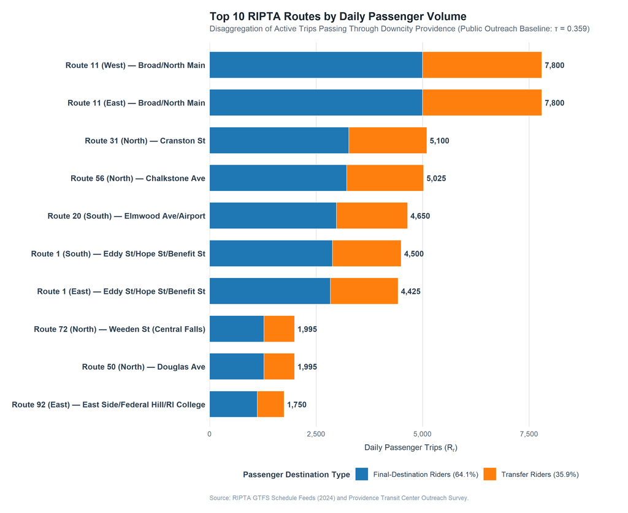

Figure 7: RIPTA Top 10 Routes by Daily Passenger Volume Disaggregated by Final-Destination Riders (64.1%) vs. Transfer Riders (35.9%).

```r
library(tidyverse)
library(ggplot2)
library(scales)

# 1. Load Route Baseline Data
csv_path  <- "../data/ripta-simulated-routes.csv"

routes_df <- read_csv(csv_path, show_col_types = FALSE)

# 1. Ingest KP Route Summary CSV
kp_route_summary <- read_csv("../data/scratch/route_kp_frequency.csv", show_col_types = FALSE)

# 2a. Modify the route summary
routes_df <- kp_route_summary |>
    mutate(
        R_r = case_when(
            trip_hdwy <= 10.1  ~ 75,  # High Frequency Corridor
            trip_hdwy <= 20    ~ 35,  # Low Frequency Corridor
            TRUE               ~ 55   # Medium Frequency Corridor
        ),
        daily_ridership = round(R_r * total_arrivals)
    )

# 2. Process Top 10 Routes by Daily Ridership
tau_survey <- 0.359 # Systemwide survey baseline transfer rate (35.9%)

top10_df <- routes_df |>
  arrange(desc(daily_ridership)) |>
  slice_head(n = 10) |>
  mutate(
    route_label = paste0("Route ", route_id, " (", approach_direction, ") — ", route_long_name),
    transfers = round(daily_ridership * tau_survey),
    dest_riders = daily_ridership - transfers
  )

# 3. Pivot to Long Format for Stacked Bar Chart
top10_long <- top10_df |>
  pivot_longer(
    cols = c("dest_riders", "transfers"),
    names_to = "passenger_type",
    values_to = "volume"
  ) |>
  mutate(
    passenger_type = factor(
      passenger_type,
      levels = c("transfers", "dest_riders"),
      labels = c("Transfer Riders (35.9%)", "Final-Destination Riders (64.1%)")
    ),
    route_label = reorder(route_label, daily_ridership)
  )

# Total ridership labels for annotations
totals_df <- top10_df |>
  mutate(route_label = reorder(route_label, daily_ridership))

# 4. Generate Publication-Quality Plot
p <- ggplot(top10_long, aes(x = route_label, y = volume, fill = passenger_type)) +
  geom_col(width = 0.7, color = "white", linewidth = 0.3) +
  geom_text(
    data = totals_df,
    aes(x = route_label, y = daily_ridership, label = comma(daily_ridership)),
    inherit.aes = FALSE,
    hjust = -0.15,
    size = 3.5,
    fontface = "bold",
    color = "#2c3e50"
  ) +
  coord_flip() +
  scale_fill_manual(
    values = c(
      "Final-Destination Riders (64.1%)" = "#1f77b4",
      "Transfer Riders (35.9%)" = "#ff7f0e"
    ),
    guide = guide_legend(reverse = TRUE)
  ) +
  scale_y_continuous(
    labels = comma_format(),
    limits = c(0, 9000),
    expand = expansion(mult = c(0, 0.05))
  ) +
  labs(
    title = "Top 10 RIPTA Routes by Daily Passenger Volume",
    subtitle = "Disaggregation of Active Trips Passing Through Downcity Providence (Public Outreach Baseline: τ = 0.359)",
    x = NULL,
    y = expression("Daily Passenger Trips (" * R[r] * ")"),
    fill = "Passenger Destination Type",
    caption = "Source: RIPTA GTFS Schedule Feeds (2024) and Providence Transit Center Outreach Survey."
  ) +
  theme_minimal(base_size = 12) +
  theme(
    plot.title = element_text(face = "bold", size = 14, color = "#1a252f", margin = ggplot2::margin(b = 4)),
    plot.subtitle = element_text(size = 10, color = "#576574", margin = ggplot2::margin(b = 12)),
    plot.caption = element_text(size = 8, color = "#8395a7", hjust = 0, margin = ggplot2::margin(t = 12)),
    axis.text.y = element_text(size = 10, face = "bold", color = "#2c3e50"),
    axis.text.x = element_text(size = 9, color = "#576574"),
    axis.title.x = element_text(size = 10, face = "bold", color = "#2c3e50", margin = ggplot2::margin(t = 8)),
    legend.position = "bottom",
    legend.title = element_text(size = 10, face = "bold", color = "#2c3e50"),
    legend.text = element_text(size = 9, color = "#2c3e50"),
    panel.grid.major.y = element_blank(),
    panel.grid.minor = element_blank(),
    panel.grid.major.x = element_line(color = "#e0e0e0", linewidth = 0.4),
    plot.margin = ggplot2::margin(15, 20, 15, 15)
  )

p
```

## 3.6 Summary of EDA Baselines & Transition to Statistical Modeling

The exploratory data analysis established four foundational baselines characterizing the operational, spatial, and socioeconomic footprint of RIPTA’s transit network centered at Kennedy Plaza:

1. **Operational Network Geometry:** Static GTFS schedule feeds confirmed that Kennedy Plaza functions as a hub-and-spoke radial terminal. In our EDA scenario, we focused on 27 high-frequency routes accommodating over 1,300 daily bus arrivals.
2. **Topographic Impedance (The Uphill Barrier):** Elevation modeling using RIGIS digital elevation models (DEM) and Tobler’s Hiking Function demonstrated that shifting the hub northward to Park Row West introduces significant uphill grade penalties **(+1.2% average grade, peaking at +2.2% on Francis Street)** that disproportionately impact walking travel times for mobility-impaired riders.
3. **Socioeconomic Vulnerability:** Census ACS demographic overlays revealed that transit corridors approaching downtown from the South and West serve areas with substantially higher poverty rates, minority populations, and zero-vehicle household concentrations than northern and eastern routes.
4. **Active Rider & Transfer Dynamics:** By applying route-volume weighting and the deterministic transfer ratio from the public outreach survey $(\tau_{survey}=0.359)$, we translated static residential demographics into an active transit rider profile, successfully isolating the daily volumes of transferring passengers versus final-destination riders.

While these EDA baselines map the physical routes and neighborhood demographics, evaluating real-world schedule delays requires actual bus tracking data. As established in Section 2.2, static GTFS schedules are insufficient for robust, real-world performance analysis. Furthermore, while RIPTA streams public-facing GTFS-Realtime feeds online, public live-tracking feeds cap download speeds (‘*API rate limits*’), making it impractical to reconstruct a full four-season historical baseline from public streams alone.

To power our operational model, a formal public records request under the Rhode Island Access to Public Records Act (APRA) was submitted to RIPTA on October 5, 2026. On October 21, 2026, RIPTA Legal Services fulfilled the request, providing a contiguous 12-month historical archive of internal agency CAD/AVL database records.

With this tracking data in hand, the study moves from static mapping to active modeling. In Section 4, we use this historical archive—combined with our upper and lower transfer demand bounds ($\tilde{\tau} \in [0.359, 0.510]$)—to design formal experiments testing how the proposed hub relocation affects schedule synchronization, transfer windows, and overall system delay.

# 4 Design of Experiments

## 4.1 Operational Delay Modeling

Localized traffic congestion and transit hub bottlenecks are primary drivers of marginal operating costs and service degradation. To evaluate the impact of relocating the central hub to Park Row West, we constructed a two-phased operational model. In **Phase 1**, we use multiple linear regression across the historical GPS records to measure how fragile the existing network already is, where $Y_{i,t}$ represents the actual driving delay (*in minutes*) for each trip $t$ on route $i$ approaching Kennedy Plaza. In **Phase 2**, we calculate the distance-and-time penalty (*deterministic spatial extension*) of rerouting buses to Park Row West, showing how extra mileage compounds existing bottlenecks.

### 4.1.1 Phase 1: Empirical Delay Model

The empirical delay model evaluates how structural operational factors compound travel times in the downtown corridor. The multivariate model is defined by:

$$Y_{i,t}=\beta_0+\beta_2X_{2(i,t)}+\beta_3X_{3(i,t)}+\beta_4X_{4(i)}+\epsilon_{i,t}$$

where:

$$\begin{array}{l}
\beta_0\text{ represents baseline delay under normal operating conditions}\\[1.5em]
X_{2(i,t)}\text{ is a time of day (peak/off-peak) factor}\\[1.5em]
X_{3(i,t)}\text{ is the observed hourly frequency for route } i \text{ on trip } t\\[1.5em]
X_{4(i)}\text{ is a categorical indicator for approach direction, with North as the reference baseline}\\[1.5em]
\epsilon_{i,t}\text{ represents variations unexplained by the model}\\[1.5em]
\end{array}$$

> *Note:* Variables $X_1$ and $X_5$ are reserved for the Phase 2 spatial extension model in Section 4.1.2.

To build this model, we combine the planned route schedules with the actual real-world tracking archive. While the CAD/AVL dataset provides the actual historical delay (the target variable, $Y_{i,t}$), the static GTFS datasets supply the independent structural features that influence performance:

1. **Time-of-Day (**$X_2$, *derived from* `stop_times.txt`**):** Peak-hour trips experience higher traffic signal delays, street congestion, and longer boarding dwell times.
2. **Trip-Frequency (**$X_3$, *derived from* `trips.txt`, `stop_times.txt`**):** Routes operating at short-headways (*e.g. corridors with buses every 5-10 minutes*) experience queuing and berth congestion when multiple buses call at the hub simultaneously.
3. **Approach Vectors (**$X_4$, *derived from* `trips.txt`, `routes.txt`, `stops.txt`**):** Inbound approach direction (North, South, East, West) dictates the specific street geometry and localized turning movements required to navigate the Downcity core.

### 4.1.2 Phase 2: Deterministic Extension Modeling

After measuring the fragility of the current schedule, we calculate the **direct travel time penalty** of the Park Row West relocation separately. This approach allows us to isolate the true impact of the new hub without injecting historical traffic bias into the simulation. The projected temporal extension penalty $(\hat{Y}_{ext(i,t)})$ in minutes for a specific trip $t$ on route $i$ is given by:

$$\hat{Y}_{ext(i,t)}=X_{1(i)} \times X_{5(i,t)}$$

where:

$$\begin{array}{l}
X_{1(i)}\text{ is the physical extension distance (mi.)}\\[1.5em]
X_{5(i,t)}\text{ is the travel time rate (min/mi.)}\\[1.5em]
\end{array}$$

To project the direct travel time penalty of relocating the hub, the simulation mathematically couples the proposed physical street geometry with the empirical travel pace of the network:

1. **Physical Extension Distance (**$X_1$ , derived via `osrm()` routing**):** The static street-level routing delta required to reach Park Row West from the existing urban perimeter.
2. **Route Travel Pace (**$X_5$, derived from `stop_times.txt`**):** Calculated from the scheduled minutes between official timetable stops, this metric measures each corridor’s **planned schedule pace** (*in minutes per mile*). Using this fixed timetable rate—rather than live GPS speeds—isolates the pure distance penalty of the extension without double-counting the historical downtown traffic.

### 4.1.3 Hypothesis Testing

Phase 1 of our empirical delay model evaluates whether peak traffic, bus frequency, and approach geometry structurally compound localized transit delays in Providence. By regressing the historical baseline delay against these operational predictors, we establish the following null hypothesis:

- $(H_0: \beta_2 = \beta_3 = \beta_4 = 0)$: Baseline operational friction on inbound transit corridors is uniform, meaning no specific approach direction, time of day, or frequency load drives compounded schedule degradation.

We reject the null hypothesis in favor of the alternative hypothesis when:

- $(H_a: \text{At least one } \beta_k \neq 0)$: Baseline operational friction is non-uniform, with specific operational factors and approach corridors driving statistically significant schedule delays.

In practical terms, rejecting $H_0$ confirms that downtown delays are not random bad luck—specific entry corridors and rush-hour schedules systematically bog buses down.

### 4.1.4 Model Performance Metrics

To compare the predictive performance and error margins of our various models, we utilize the following standard regression metrics:

- **R-squared** $(R^2)$**:** A statistical measure of fit that indicates the proportion of the variance in the trip delay $(Y)$ that is explained by the model’s independent variables.
- **Mean Absolute Error (MAE):** The average absolute gap between the model’s predictions and the actual historical trip delays. Measured in minutes, MAE tells schedulers how far off the model’s prediction is on a **typical** trip:

$$\text{MAE}=\frac{1}{N} \sum_{i} |\hat{y}_{i}-y_{i}|$$

- **Root Mean Squared Error (RMSE):** While the MAE treats all errors equally, the **Mean Squared Error (MSE)** squares each residual, heavily penalizing large estimation outliers. RMSE applies the square root to the MSE to return the error metric in the same temporal units of the outcome:

$$\text{RMSE}=\sqrt{\text{MSE}}= \sqrt{\frac{1}{N} \sum_{i} (\hat{y}_{i}-y_{i})^2}$$

### 4.1.5 CAD/AVL and GTFS Data Integration

To construct the analytical matrix for the Operational Delay Model, 12 months of agency CAD/AVL transit event records (`data/ripta_avl_1yr_log.csv`) were combined with GTFS reference files (`data/gtfs_merged_1yr/{trips.txt, stops.txt}`) and corridor scoping definitions (`data/kp_route_summary.csv`).

#### 4.1.5.1 Scoping the Study Area

Because RIPTA operates statewide, the records were first scoped to focus exclusively on corridors serving Downcity Providence. The master corridor reference depicted in Fig. 4 and tabulated in `data/kp_route_summary.csv` defines the **27 fixed bus routes** operating across **30 distinct directional corridor legs** that terminate at or pass through Kennedy Plaza.

#### 4.1.5.2 Schema Normalization & Operational Trip Identification

The CAD/AVL database contains thousands of raw event records tracking the scheduled and actual movements of every bus. From these raw records, we extracted: (1) unique operational trip identifiers (`op_trip_id = paste(TripIdExternal, run_date, sep = "_")`); (2) schedule deviation in seconds (`arrival_delay_s = difftime(IncidentDateTime, ScheduleTime)`); (3) high-precision stop GPS coordinates (`BusStopLatitude`, `BusStopLongitude`); and (4) timepoint classifications (`TimePointShortName`, `TimePointLongName`).

#### 4.1.5.3 Decision Timepoint Isolation & Spatial Routing

To evaluate the baseline fragility of the network, the pipeline isolates each trip’s **decision timepoint** $(P_i)$—the final scheduled timepoint served prior to encountering Kennedy Plaza berths (`TimepointShortName == "kepl"` or stops `16400`, `16435`, `16475`, `16485`). By freezing schedule deviation at $P_i$, the model captures incoming corridor delay before vehicles enter Downcity terminal queuing—ensuring we don’t unfairly blame Park Row West for bus backups that currently happen inside Kennedy Plaza itself! This isolated schedule deviation serves as the empirical dependent variable $Y_{i,t}$ for the Phase 1 statistical impact model.

For the Phase 2 deterministic extension simulation, the `osrm` package’s `osrmRoute()` function is utilized to calculate two distinct spatial trajectories from the decision timepoint $P_i$: the existing baseline distance to Kennedy Plaza, and the proposed distance to the Park Row West terminal centroid (`coord_prw_fs = c(-71.4136, 41.8296)`). The **extension distance** $X_{1(i)}$ for each route is mathematically derived by subtracting the baseline network distance from the relocated terminal distance:

$$X_{1(i)}=d(P_i,\text{Park Row West})-d(P_i,\text{KP})$$

These physical routing distances were merged with the empirical delay variable, trip-level peak indicators, dynamic corridor frequencies, and travel time rates to assemble the dual-framework analytical matrix (`data/ripta_kp_final_dataset.csv`).

### 4.1.6 Characterization of the Dataset and Summary Statistics

The final analysis matrix represents **30 distinct route-approach corridors** derived from **353,095 unique inbound bus trips** spanning a full operational year (*October 1, 2025 – September 30, 2026*):

- **Data Ingestion &** $1:1$ **Trip Reduction:** RIPTA’s 1-year CAD/AVL log was processed through a deduplication filter, ensuring each of the **353,095 inbound bus runs** is counted exactly once at its downtown gateway stop $(P_i)$.
- **Baseline Empirical Delay** $(Y)$**:** Measured at the upstream decision stop $P_i$ prior to applying any spatial relocation penalties. After filtering out incomplete records and extreme sensor outliers, the remaining **335,924 viable model observations** averaged **+2.86 minutes** (*median: +1.97 minutes; interquartile range: -0.07 to +4.63 minutes*). This observed distribution captures real-world operating conditions, including weather events and major traffic disruptions (*maximum recorded delay: ~860 minutes, reflecting major snowstorms or severe gridlock events*). When grouped by approach vector, existing schedule friction is most severe along the South (**+3.60 minutes**) and North (**+2.95 minutes**) corridors, exceeding the lower baseline delays observed on the West (**+2.80 minutes**) and East (**+2.47 minutes**) routes.
- **Peak Hour Traffic Factor** $(X_2)$**:** A binary temporal control indicating trips operating within peak windows (*07:00-09:00 or 16:00-18:00*), accounting for ~**33%** of evaluated trip instances.
- **Trip Frequency** $(X_3)$**:** Represents the scheduled density of service on a given route corridor. Dynamic vehicle throughput averaged **5.58 buses per hour** (*roughly a 10.8 min headway*), ranging from a minimum of **2.12 buses/hr** (*Route 40 Butler/Elmgrove*) during off-peak hours to a maximum of **10.4 buses/hr** (*Route 20 Elmwood*) during peak hours.
- **Approach Direction** $(X_4)$**:** Captures the severe infrastructural friction inherent to navigating primary entry vectors (Fig. 3), utilizing the North approach as the statistical baseline.
- **Terminal Extension Distance** $(X_1)$**:** Used exclusively for Phase 2 deterministic simulation. By calculating the difference between the baseline network routing to Kennedy Plaza and the proposed routing to Park Row West (`osrmRoute()`), the model established an average spatial extension penalty of **0.059 miles** (*312 feet*) across all evaluated trips. Reflecting Providence’s asymmetric radial geography, routing distances vary significantly by cardinal approach vector:
  - **North Approach (Truncated Savings):** Uniquely experiences a spatial savings, reducing the travel distance by an average of **-0.14 miles** (-*739 ft*) as inbound routes terminate at the proposed hub before entering the deep Downcity core.
  - **West, East, and South Approaches (Severe Penalties):** Experience significant routing burdens as they are forced to traverse the urban grid to reach the northern hub, adding average extensions of **0.21 miles** for the West, **0.20 miles** for the East, and **0.21 miles** for the South.
- **Route Travel Pace** $(X_5)$**:** Used exclusively for Phase 2 deterministic simulation. A calculated baseline pace (*min/mi*) reflecting the structural friction of each route based on stop density. Rates averaged **3.26 min/mi** across all evaluated corridors, ranging from **2.80 min/mi** (*Route 31 Cranston St.*) to **3.76 min/mi** (*Route 14 West Bay*), providing a clean baseline for extension simulation by filtering out historical downtown gridlock.

### 4.1.7 Temporal Delay vs. Route-Level Extension

The deterministic relationship between the physical re-routing extension $(X_{1(i)})$ and projected marginal delay $(\hat{Y}_{ext(i)})$ for each route is depicted in Fig. 8 below. By isolating just the extra physical distance, the plot depicts a direct linear relationship: as inbound routes get longer, their projected delays scale predictably along the main trendlines. Notably, routes positioned in the bottom-left quadrant experience negative distance deltas, indicating that terminating at Park Row West truncates their inbound path and offers a marginal time savings.

However, evaluating these deterministic spatial penalties requires historical context from the empirical data: while the spatial math is linear, stacking these spatial penalties on top of already-fragile Southern approaches—which experience severe baseline traffic delays—or imposing steep new burdens on the Eastern and Western corridors threatens to trigger cascading network failures.

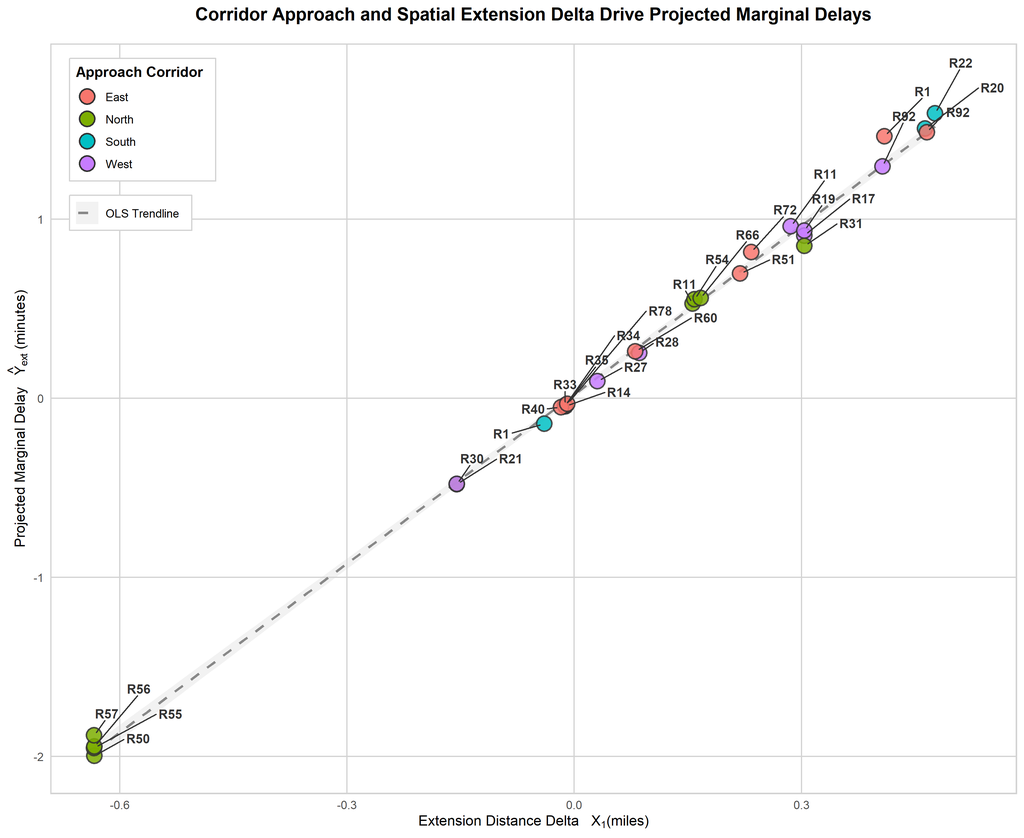

Figure 8: Projected Marginal Delay ($\hat{Y}_{ext}$) vs. Physical Extension Distance ($X_1$) Disaggregated by Approach Corridor.

```r
library(tidyverse)
library(ggplot2)
library(scales)
library(ggrepel)

# 1. Load Route Baseline Data
csv_path  <- "../data/ripta_kp_final_dataset.csv"

# Load the raw 365-day dataset
raw_dataset <- read_csv(csv_path, show_col_types = FALSE)

# Aggregate down to the 29 routes
route_summary <- raw_dataset |>
  group_by(route_id, approach_direction) |>
  summarize(
    route_ext_distance_miles = mean(route_ext_distance_miles, na.rm = TRUE),
    temporal_delay_mins      = mean(temporal_delay_mins, na.rm = TRUE),
    .groups                  = "drop"
  )

# 2. Generate Scatter Plot
p <- route_summary |>
  ggplot(aes(x = route_ext_distance_miles, y = temporal_delay_mins)) +
  geom_smooth(
    aes(linetype = "OLS Trendline"),
    method = "lm",
    se = TRUE,
    color = "#888888",
    size = 1,
    fill = "lightgray",
    alpha = 0.3
  ) +

  geom_point(aes(fill = approach_direction), shape = 21, color = "#333333", size = 5, stroke = 1, alpha = 0.85) +

  geom_text_repel(
    aes(label = paste0("R", route_id)),
    size = 3.5,
    fontface = "bold",
    color = "#333333",
    box.padding = 0.4,
    point.padding = 0.3,
    nudge_x = 0.05,
    nudge_y = 0.2
  ) +

  scale_fill_manual(
    values = c(
      "East" = "#F8766D",
      "North" = "#7CAE00",
      "South" = "#00BFC4",
      "West" = "#C77CFF"
    ),
    name = "Approach Corridor"
  ) +

  scale_linetype_manual(
    values = c("OLS Trendline" = "dashed"),
    name = NULL
  ) +

  labs(
    title = "Corridor Approach and Spatial Extension Delta Drive Projected Marginal Delays",
    x = expression(paste("Extension Distance Delta   ", X[1], "(miles)")),
    y = expression(paste("Projected Marginal Delay   ", hat(Y)[ext], " (minutes)"))
  ) +

  theme_minimal(base_family = "sans") +
  theme(
    plot.title = element_text(face = "bold", size = 14, hjust = 0.5, margin =
                                  ggplot2::margin(b = 15)),
    axis.title = element_text(size = 11),
    panel.border = element_rect(color = "lightgray", fill = NA, size = 1),
    panel.grid.major = element_line(color = "lightgray", size = 0.5),
    panel.grid.minor = element_blank(),
    legend.position = c(0.02, 0.98),
    legend.justification = c(0, 1),
    legend.background = element_rect(fill = "white", color = "lightgray", size = 0.5),
    legend.title = element_text(face = "bold"),
    legend.margin = ggplot2::margin(t = 5, r = 10, b = 5, l = 5)
  ) +

  guides(
    fill = guide_legend(override.aes = list(size = 5, alpha = 1), order = 1),
    linetype = guide_legend(order = 2)
  )

p
```

By merging these deterministic physical penalties with our historical empirical delay models, we can systematically evaluate compounding downstream vulnerabilities in the following areas:

- **Outlier Vulnerability:** We evaluate the operational fragility of approach corridors by combining these spatial penalties with empirical historical variance, investigating whether total travel times compound exponentially during peak congestion windows or severe weather conditions.
- **Demographic Impact:** We intersect these combined delay models with regional block group data to determine if the heaviest structural route penalties disproportionately burden transit-dependent, low-income, and minority communities traversing these specific corridors.
- **Systemic Cascading:** We utilize the maximum empirical delays observed in the network as a failure threshold, modeling how inbound scheduling degradation—compounded by physical hub extension—increases the probability of missed passenger transfers across the broader Providence transit grid.

## 4.2 Operating Costs and Fleet Requirements

The temporal driving delays $(\hat{Y}_{ext(i)})$ established by deterministic simulation (Section 4.1.7) and quantified in Section 5.1.3 serve as direct quantitative inputs to estimate downstream financial and fleet burdens. When terminal relocation expands round-trip cycle times, RIPTA must absorb additional vehicle service hours and deploy extra vehicles to maintain existing schedule headways.

To quantify the financial and operational consequences of relocating central transit operations from KP to Park Row West, three standard Federal Transit Administration (FTA) metrics are derived across all 30 evaluated routes:

1. **Annual Additional Vehicle Revenue Hours** $(\Delta \text{VRH})$**:** Assuming the spatial delay is incurred both inbound and outbound from the new hub, temporal delay ($\hat{Y}_{ext(i)}$*, in minutes*) is doubled per two-way round-trip. This two-way penalty is multiplied by the scheduled daily inbound trip volume $(\text{Daily Trips}_i)$ and annualized over a 365-day operation calendar:

$$\Delta \text{VRH}=\sum_{i=1}^{30} \left( \frac{2 \times \hat{Y}_{ext(i)} \times \text{Daily Trips}_i}{60} \right) \times 365$$

2. **Annual Marginal Operating Cost** $(\Delta \text{OpsCost})$**:** Additional annual vehicle service hours are multiplied by RIPTA’s system-wide unit operating cost per revenue hour ($C_{\text{hr}} =\$168.77 /\text{hour}$*, benchmarked from National Transit Database (NTD) reporting standards for Fixed-Route Bus operations in mid-sized urbanized areas*)[^19]:

$$\Delta \text{OpsCost} = \Delta \text{VRH} \times C_\text{hr}$$

3. **Vehicles Operating in Maximum Service (VOMS):** Measures the additional physical buses required during peak operation hours to absorb cycle time expansion without degrading service frequency ($h_i$*, peak scheduled headway in minutes*). Because fractional vehicles cannot be deployed, a mathematical ceiling function $(\left\lceil \dots \right\rceil)$ rounds the fleet requirement up to the nearest whole bus:

$$\Delta \text{VOMS} = \left\lceil \sum_{i=1}^{30} \frac{2 \times \hat{Y}_{ext(i)}}{h_i} \right\rceil$$

## 4.3 Equity & Rider Accessibility Impacts

### 4.3.1 Experimental Scenario & Public Equity Framework

We now shift focus from the Operational Delay model, which quantifies the temporal and financial burdens placed upon RIPTA’s physical fleet, to a model that comprehensively evaluates the pedestrian impacts and demographic equity of the hub relocation. This requires the analytical framework to shift from *vehicle-centric* efficiency to *pedestrian* spatial equity.

The following experiment evaluates the “pedestrian displacement penalty”—the physical and temporal barrier introduced when a centralized transit hub is decommissioned and pushed to the periphery of a downtown grid. In this simulated bi-directional scenario, Kennedy Plaza is rendered defunct, and Park Row West / Providence Station serves as the sole origin point for regional transit. We hypothesize that by shifting the hub away from the dense downtown commercial and civic core (*Downcity*), passengers attempting to enter or leave the city will face a severe “first-mile/last-mile” degradation in service. Crucially, we investigate whether this access penalty disproportionately harms Transit-Dependent and Mobility-Challenged populations who lack alternative transportation modes.

To isolate this pedestrian impact, the 1-year historical CAD/AVL log is repurposed to simulate pedestrian logistics. We evaluate both ingress (*inbound*) and egress (*outbound*) trips that historically service Kennedy Plaza, projecting the downstream time penalties incurred by forcing these established passenger volumes to independently navigate the spatial gap between the new Park Row West hub and the traditional Downcity core.

### 4.3.2 Experimental Conditions & Stochastic Assumptions

Following formal data inquiries, RIPTA confirmed it does not maintain terminal-level sensor counts (APC) or origin-destination transfer logs. Because exact pedestrian counts cannot be observed directly, we built a stochastic Monte Carlo simulation—running 1,000 randomized trials per bus trip across realistic ranges of crowd sizes, walking speeds, and shuttle wait times—governed by the following spatial, demographic, and behavioral rules:

- **Standardized Spatial Anchors:** To ensure a controlled comparison of pedestrian delay, the spatial geometry is standardized. Outbound displaced riders originate from the defunct Kennedy Plaza locale (*Coordinates: 41.8250, -71.4110*) and navigate to Park Row West (*Coordinates: 41.8296, -71.4136*). Inbound displaced riders alight at Park Row West and navigate Downcity to Kennedy Plaza. As illustrated in Fig. 9, all pedestrians follow the same primary isochrone path, which standardizes the topographic elevation constraint (*1.05 m to 9.56 m, or ~28 ft of net climb along the standardized hub-to-hub path, yielding +1.85% average net grade*) used to calculate baseline delay.

[figure not shown]

Figure 9: Standardized 1,820-Foot Pedestrian Isochrone Path and Topographic Elevation Profile from Kennedy Plaza to Park Row West.

- **Tobler’s Downhill Normalization:** To accurately model this bi-directional flow, Tobler’s Hiking Function was used to normalize the downhill pedestrian advantage. Navigating inbound (*downhill at a -1.85% average net grade*) yields a structural speed advantage of 13.8% over the outbound (*uphill at a +1.85% average net grade*). Consequently, for all inbound trips, a 1.138 multiplier is applied to both the physical walking pace and the probabilistic willingness to walk, increasing the volume of riders who elect to walk rather than wait for the southbound shuttle.
- **Target Population & Equity Segmentation:** The experiment evaluates historical riders boarding outbound or alighting inbound routes. For each simulated trip, the total boarding volume ($n$) is segmented into three equity cohorts (*Transit-Dependent, Mobility-Challenged, and Non-Vulnerable*) based on the route’s weighted American Community Survey demographic profile.
- **The Displaced Rider Rate** $(D)$**:** Not all passengers originate or terminate in the immediate Downcity core. The share of riders specifically disrupted by the hub relocation is modeled as a random variable representing the final-destination rider rate—defined as the complement of the hub transfer rate $(D=1-\tilde{\tau})$. Because passenger volumes across routes and times of day are heavily right-skewed by rush-hour corridors, we anchor $\tilde{\tau}$ as a sample median $(\tilde{\tau} \in [0.359, 0.510])$ rather than skewed route-volume means. Preventing high-volume outliers from distorting the baseline yields simulated displacement bounds of **49.0% to 64.1%** on any given trip.
- **Modal Split Decision Tree:** Once a passenger is designated as part of the displaced rider cohort, they must choose how to navigate the spatial gap. The simulation applies a probabilistic behavioral split based on the rider’s physical capabilities and the direction of travel:
  - **Mobility-Challenged Cohort:** Due to the physical strain of the topographic climb, the vast majority of this cohort (*~90%*) will take the R-Line shuttle bus (*Northbound for outbound trips; Southbound for inbound trips*). The remaining fraction will attempt the physical walk. For inbound downhill trips, the walking probability bounds (*1% to 10%*) are scaled up by the 1.138 Tobler multiplier.
  - **Transit-Dependent & Non-Vulnerable Cohorts:** Able-bodied riders are assigned a baseline 20% to 30% probability of walking the isochrone path, with the remainder opting to wait for the R-Line shuttle. For inbound downhill trips, these walk probability bounds are also scaled up by the 1.138 Tobler multiplier.

**Total Displacement Time Penalty:** The ultimate metric of human impact is the total time penalty absorbed to navigate the hub displacement. Because the direction of travel dictates logistics, the simulation calculates this penalty using two distinct temporal frameworks:

- **Outbound (Deadline-Driven):** For outbound riders, the scheduled departure time from Park Row West acts as a strict deadline. The penalty represents how much *earlier* a passenger must arrive at the Kennedy Plaza shuttle stop to successfully navigate the spatial gap and catch their bus on time.
  - For **walkers**, the penalty is simply the physical travel time required to walk the uphill isochrone path (*e.g., leaving KP 7.5 minutes before the scheduled Park Row West departure to complete the uphill walk*).
  - For **R-Line shuttle takers**, the simulation calculates this penalty by querying the historical CAD/AVL log for the *latest* possible scheduled R-Line North departure from KP that successfully arrives at Park Row West prior to the outbound bus’s departure. The penalty is the total time elapsed between this required KP shuttle departure and the outbound bus’s Park Row West departure.
- **Inbound (Delay-Driven):** For inbound riders, the penalty clock begins the moment their bus actually arrives at Park Row West, representing how much *later* they reach their final Downcity destination at KP.
  - For **walkers**, the penalty is the physical travel time required to walk the downhill isochrone path (6.62 minutes for able-bodied passengers).
  - For **R-Line shuttle takers**, the simulation calculates this penalty by querying the historical CAD/AVL log for the *next available* R-Line South departure from Park Row West. The penalty is the total time elapsed between their initial bus arrival at Park Row West and the shuttle’s actual arrival at KP.

### 4.3.3 Experimental Scope & Equity Filtering

To ensure the displaced rider simulation accurately reflects real-world network logistics, the experimental scope is strictly bounded to the bi-directional traffic flowing through the proposed transit center footprint. We started by filtering the 1-year historical CAD/AVL log for all unique trip observations serving Providence Station (`psta`)—the closest geographic proxy for the Park Row West terminal. However, filtering for `psta` alone misses high-frequency routes that historically terminated short of the rail station at Kennedy Plaza (`kepl`).

To capture both sets of routes in a single unified dataset, trips containing a historical `psta` stop were isolated directly, while legacy routes terminating at Kennedy Plaza used their historical `kepl` arrival and departure timestamps as a schedule proxy, with vehicle coordinates reassigned to the proposed Park Row West location. This establishes a complete baseline of displaced rider traffic, with all inbound and outbound trips standardized to the proposed Park Row West hub coordinates.

To accurately classify the equity implications of these disrupted bi-directional corridors, the experiment imports the spatial layer (`data/scratch/providence_census_3group_demographics.gpkg`) constructed during the earlier Exploratory Data Analysis phase. This GeoPackage contains the Providence County census block group polygons, fully attributed with U.S. Census population data and pre-classified into the three socioeconomic vulnerability tiers: Transit-Dependent, Mobility-Challenged, and Non-Vulnerable. As illustrated in Fig. 10, this spatial layer establishes the geographic baseline of the demographic landscape and the transit lines converging on the proposed hub footprint.

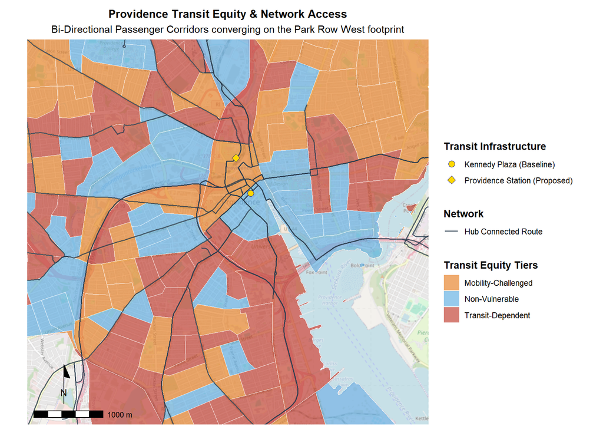

Figure 10: Providence County Block Group Equity Classification and Bi-Directional Transit Corridors.

```r
library(tidyverse)
library(sf)
library(ggspatial)
library(rosm)
library(tidytransit)

# 1. Load the spatial demographic data and force it to WGS84
census_sf <- st_read("../data/scratch/providence_census_3group_demographics.gpkg", quiet = TRUE) |>
  st_transform(4326)

# 2. Extract Route Shapes from Raw GTFS
gtfs <- read_gtfs("../data/gtfs_raw_1yr/RIPTA-GTFS.zip")

# Automatically TRUE for PDF renders, FALSE for HTML and interactive work
is_pdf <- isTRUE(knitr::pandoc_to("latex")) || isTRUE(knitr::pandoc_to("pdf")) || knitr::is_latex_output()

# Load the target routes dynamically from the source CSV dataset
equity_routes <- read_csv("../data/scratch/ripta_equity_routes.csv", show_col_types = FALSE)
target_routes <- unique(as.character(equity_routes$route_id))

route_shapes_sf <- shapes_as_sf(gtfs$shapes) |>
  inner_join(gtfs$trips |>  distinct(shape_id, route_id), by = "shape_id") |>
  filter(route_id %in% target_routes) |>
  group_by(route_id) |>
  slice(1)  |>
  ungroup()  |>
  st_transform(4326) # Force route shapes to WGS84 for mapping

# 3. Define the hub coordinates (Already in WGS84)
hubs <- data.frame(
  Hub = c("Kennedy Plaza (Baseline)", "Providence Station (Proposed)"),
  lon = c(-71.4110, -71.4136),
  lat = c(41.8250, 41.8296)
) |>
  st_as_sf(coords = c("lon", "lat"), crs = 4326)

# 4. Define the bounding box for the Downcity Providence zoom
zoom_bbox <- coord_sf(
  xlim = c(-71.450, -71.380),
  ylim = c(41.795, 41.845),
  crs = 4326,
  expand = FALSE
)

# 5. Construct the plot
ggplot() +
  # Base Map Tile Overlay
  annotation_map_tile(type = "osm", zoom = 14, alpha = 0.6) +

  # Census Block Groups colored by Equity Tier
  geom_sf(data = census_sf, aes(fill = study_group), color = "white", linewidth = 0.1, alpha = 0.65) +

  # RIPTA Bus Routes: Mapped color to an aesthetic to generate a legend entry
  geom_sf(data = route_shapes_sf, aes(color = "Hub Connected Route"), linewidth = 0.6, alpha = 0.8) +

  # Transit Hubs: Removed stroke and fill, reduced size
  geom_sf(data = hubs, aes(shape = Hub), color = "darkblue", fill = "gold", size = 3) +

  scale_fill_manual(
    name = "Transit Equity Tiers",
    values = c(
      "Transit-Dependent" = "#C0392B",
      "Mobility-Challenged" = "#E67E22",
      "Non-Vulnerable" = "#5DADE2"
    )
  ) +
  scale_shape_manual(
    name = "Transit Infrastructure",
    # 16 is a solid circle, 18 is a solid diamond
    values = c("Kennedy Plaza (Baseline)" = 21, "Providence Station (Proposed)" = 23)
  ) +
  # New scale to handle the route line legend
  scale_color_manual(
    name = "Network",
    values = c("Hub Connected Route" = "#2C3E50")
  ) +

  annotation_scale(location = "bl", width_hint = 0.25) +
  annotation_north_arrow(location = "bl", which_north = "true",
                         pad_x = unit(0.25, "in"), pad_y = unit(0.3, "in"),
                         style = north_arrow_minimal) +

  zoom_bbox +
  theme_minimal(base_family = "sans") +
  theme(
    panel.grid.major = element_line(color = "gray90", linetype = "dashed"),
    panel.background = element_rect(fill = "#F4F6F6", color = NA),
    legend.position = "right", # Moved to the right to open up map whitespace
    legend.box = "vertical",
    legend.title = element_text(face = "bold"),
    axis.text = element_blank(),
    axis.title = element_blank(),
    plot.title = element_text(face = "bold", size = 12, hjust = 0.5),
    plot.subtitle = element_text(hjust = 0.5),
    plot.margin = ggplot2::margin(10, 15, 10, 15)
  ) +
  labs(
    title = "Providence Transit Equity & Network Access",
    subtitle = "Bi-Directional Passenger Corridors converging on the Park Row West footprint"
  )
```

A population-weighted spatial intersection was then executed (`sf`) to map the active bus routes against these demographic boundaries. Rather than classifying routes based merely on the physical miles driven through a block group, the spatial segment lengths were multiplied by the block group’s U.S. Census population density. This population-weighted exposure metric ensures that a route’s dominant equity tier is dictated by the actual volume of vulnerable residents it serves, rather than empty highway miles. By ranking these bi-directional corridors by aggregate passenger volume, Fig. 11 visually confirms that the highest-volume routes in the network are predominantly carrying the city’s most vulnerable riders.

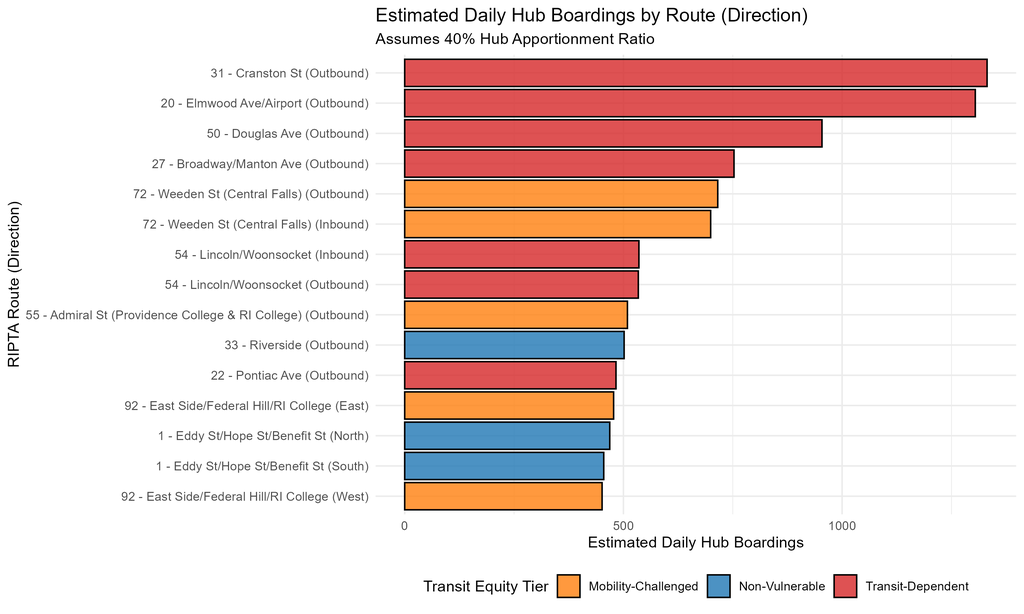

Figure 11: Estimated Daily Hub Boardings by Bi-Directional Route, Categorized by Dominant Equity Tier.

RIPTA does not publish exact passenger boarding counts for its transit hubs. To model this pedestrian disruption, we must use a step-by-step mathematical approach to estimate exactly how many people are attempting to board or alight each affected bus:

1. **Total Ridership** $(R_r)$**:** First, the empirical daily trip count for each route is multiplied by its equity-assigned passenger load factor (*75/55/35 passengers, see Table 6*) to estimate the total daily passengers serviced across the entire length of the corridor.
2. **Expected Hub Boardings** $(\lambda)$**:** In radial transit networks, the central business district (CBD) hub functions as the network’s maximum load segment—the location carrying the highest concentration of passengers[^20]. While total daily boardings across the entire length of a route are considerably greater than the volume at this single segment due to continuous passenger turnover, the exact proportion of riders boarding at the hub is unknown without APC data. To conservatively estimate these pedestrian volumes for the simulation, the Hub Apportionment Ratio $(H)$ is treated as a continuous random variable drawn from a uniform distribution $(H \sim U(0.30, 0.50))$, operating under the assumption that 30% to 50% of the route’s daily volume originates at the central hub. For every simulated trip, $R_r$ is multiplied by this stochastic ratio and scaled by the hour-of-day temporal weight $(W_t)$—an empirical multiplier derived from the CAD/AVL log that represents the proportion of daily traffic occurring during that specific hour. This generates $\lambda$, which represents the **total expected number of passengers physically exiting or entering the bus at the Park Row West hub**.
3. **Transfer vs. Displaced Rider Apportionment:** Not everyone utilizing the hub is navigating to or from Downcity; some transferred from other buses or arrived by train. The simulation draws from the Displaced Rider Rate $(D_r \sim U(0.490, 0.641))$ and executes a Binomial experiment to split the total boardings $(n \sim \text{Poisson}(\lambda))$ into Transfer Riders and Displaced Riders.
4. **Pedestrian vs. Shuttle Modal Split:** Finally, the isolated cohort of Displaced Riders must navigate the 1,820-foot (0.34-mile) spatial gap between Park Row West and KP. The simulation applies a stochastic probabilistic split based on the route’s equity tier, grounded in pedestrian access thresholds from the *Transit Capacity and Quality of Service Manual (TCQSM)*[^21]. Because the extension exceeds the standard 0.25-mile acceptable walking distance for 75% to 80% of transit users, able-bodied cohorts (*Transit-Dependent and Non-Vulnerable*) are assigned a walking probability drawn from a uniform distribution $(Able\text{\_}Walk \sim U(0.20, 0.30))$, routing the vast majority into the R-Line shuttle queue. For Mobility-Challenged riders, the compounding effects of a 3.3 ft/s mobility speed reduction for older adults and the topographical grade render the walk physically prohibitive, severely constraining their walking probability $(Mobility\text{\_}Walk \sim U(0.01, 0.10))$. Crucially, both of these probability bounds are multiplied by 1.138 for inbound downhill trips to reflect Tobler’s structural speed advantage.

These spatial parameters, behavioral distributions, and equity constraints provide the mathematical foundation for the Monte Carlo pedestrian simulation. Table 9 details the complete experimental design, distinguishing the deterministic spatial constants from the stochastic passenger variables used to calculate the final Time-to-Board degradation penalty.

Table 9: Monte Carlo Simulation Run Matrix for Bi-Directional Pedestrian Impacts

| Parameter Specifications Parameter / Variable | Parameter Specifications Type | Parameter Specifications Distribution / Value |
| --- | --- | --- |
| Spatial Isochrone Path | Static Constant | 1,820 ft (Outbound: +1.85% grade, Inbound: -1.85% grade) |
| Tobler's Inbound Multiplier | Static Constant | \(1.138\) (13.8% downhill speed & probability advantage) |
| Time-of-Day Multiplier (\(W_t\)) | Empirical Rate | Derived from AVL Hourly Frequency |
| Expected Hub Volume (\(\lambda\)) | Calculated Mean | \(\lambda = R_r \times H \times W_t\) |
| Simulated Hub Boardings (\(n\)) | Stochastic Draw | \(n \sim \text{Poisson}(\lambda)\) |
| Hub Apportionment Ratio (\(H\)) | Stochastic Draw | \(H \sim U(0.30, 0.50)\) |
| Displaced Rider Rate (\(D\)) | Stochastic Draw | \(D \sim U(0.490, 0.641)\) |
| Displaced Riders | Stochastic Draw | \(\text{Displaced} \sim \text{Binomial}(n, D)\) |
| Mobility-Challenged Walk Split | Stochastic Draw | \(U(0.01, 0.10)\) *scaled by 1.138 if inbound* |
| Able-Bodied Walk Split | Stochastic Draw | \(U(0.20, 0.30)\) *scaled by 1.138 if inbound* |

With the three experimental frameworks established—operational delay modeling, financial impacts and fleet sizing, and stochastic equity simulation—we now turn to the empirical outputs. In the following section, we execute these models against RIPTA’s 12-month CAD/AVL archive to quantify the exact operational, fiscal, and human costs of relocating Providence’s central transit hub to Park Row West.

# 5 Analysis & Results

In this section, we run our three models against RIPTA’s 12-month CAD/AVL dataset. First, we use hierarchical linear regression to measure baseline delays across the current network. From there, we project the added travel times, fleet costs, and pedestrian impacts of moving the central hub to Park Row West.

## 5.1 Operational Delay Model

We begin with linear regression to quantify the structural associations between the operational variables and formally test our empirical hypothesis $(H_0)$. The operational delay model evaluation script is available at `scripts/test_03_model_a_operational_delay.R`. To isolate how schedule density and legacy street geometry compound localized transit friction—prior to simulating the physical hub relocation—we utilize a hierarchical (*3-block*) linear regression framework:

- **Block 1 (Baseline Traffic Regime – Time-of-Day Factor):**

$$Y_{i,t}=\beta_0+\beta_2X_{2(i,t)}+\epsilon_{i,t}$$

- **Block 2 (Traffic + Frequency Impacts):**

$$Y_{i,t}=\beta_0+\beta_2X_{2(i,t)}+\beta_3X_{3(i,t)}+\epsilon_{i,t}$$

- **Block 3 (Full Specification with Corridor Geometry):**

$$Y_{i,t}=\beta_0+\beta_2X_{2(i,t)}+\beta_3X_{3(i,t)}+\beta_4X_{4(i)}+\epsilon_{i,t}$$

### 5.1.1 Hierarchical Regression Estimates

As detailed in Table 10, the hierarchical linear regression models evaluate the empirical baseline delay prior to any simulated spatial extension. By transitioning to a trip-level delay model (*335,924 viable inbound observations*), we strip out the deterministic spatial components to purely evaluate real-world operational friction. Predicting the exact delay of a single bus trip over a full year is inherently noisy due to random daily traffic events, which results in a low overall $R^2$. Because our goal here is diagnosing systemic bottlenecks rather than predicting individual daily arrivals, **statistical significance—not** $R^2$**—is the decisive metric**, and the extremely low $p$-values $(p<0.001)$ confirm that these delays are structural features of the network rather than random chance.

Table 10: Hierarchical OLS Regression Estimates for Baseline Inbound Corridor Delay (N = 335,924).

| Hierarchical OLS Regression Comparison Predictor / Metric | Hierarchical OLS Regression Comparison Model 1 (Baseline Traffic Regimes) | Hierarchical OLS Regression Comparison Model 2 (Traffic + Frequency Impacts) | Hierarchical OLS Regression Comparison Model 3 (Full Specification) |
| --- | --- | --- | --- |
| (Intercept) | 2.6425 (t = 103.37, p < 0.001) | 2.4454 (t = 53.04, p < 0.001) | 2.6877 (t = 46.78, p < 0.001) |
| Peak Time-of-Day Factor (X2) | 0.6605 (t = 14.81, p < 0.001) | 0.6173 (t = 13.60, p < 0.001) | 0.6426 (t = 14.15, p < 0.001) |
| Trip Frequency (X3) | — | 0.0379 (t = 5.14, p < 0.001) | 0.0087 (t = 1.12, p = 0.2642) |
| Approach: South (X4) | — | — | 0.6209 (t = 8.95, p < 0.001) |
| Approach: East (X4) | — | — | -0.4750 (t = -9.22, p < 0.001) |
| Approach: West (X4) | — | — | -0.1194 (t = -1.98, p = 0.0476) |
| R² | 0.0007 | 0.0007 | 0.0014 |

**Model 1 (Baseline Traffic Regimes)** established a fundamental structural delay across the network with an off-peak intercept of **+2.6425 minutes** $(p<0.001)$, while demonstrating that peak-hour $(X_2)$ traffic conditions independently compound delays by an additional **+0.6605 minutes** $(p<0.001)$. Incorporating trip frequency $(X_3)$ in **Model 2** demonstrates that scheduled service density structurally compounds localized delays, contributing to a statistically significant **+0.0379 minutes** per additional bus per hour $(p<0.001)$, even when controlling for peak-hour traffic.

The full-specification framework (**Model 3**) achieves the highest overall goodness of fit $(R^2=0.0014)$ and is selected as the primary analytical framework because it isolates cardinal-specific approach geometry alongside temporal factors. In this full specification, system-wide peak-hour traffic conditions independently compound delays by an additional **+0.6426 minutes (~39 seconds)** $(p<0.001)$. However, the existing Downcity grid proves equally disruptive: Southern approach routes face a severe, statistically significant **+0.6209-minute (~37-second)** penalty relative to the Northern reference approach $(p<0.001)$. Conversely, because delay is measured at the Downcity perimeter, the Eastern and Western approaches arrive **faster** than the Northern baseline, experiencing marginal time savings of **-0.4750 minutes** $(p<0.001)$ and **-0.1194 minutes** $(p=0.0476)$, respectively. Notably, once the approach geometry is accounted for in **Model 3**, trip frequency loses its statistical significance $(p=0.2642)$. This indicates that approach corridor geometry—particularly along the Southern corridor—is the dominant driver of existing network fragility, establishing the baseline upon which the spatial extension to Park Row West will be applied.

To formally confirm whether the incremental variance $(\Delta R^2)$ explained by these added variables is statistically significant beyond baseline temporal traffic patterns, we perform a sequential Analysis of Variance (ANOVA) test (Table 11).

Table 11: Sequential Analysis of Variance (ANOVA) Comparing Nested Operational Delay Models.

| Sequential ANOVA Model Comparison Model | Sequential ANOVA Model Comparison Res. Df | Sequential ANOVA Model Comparison RSS | Sequential ANOVA Model Comparison Df | Sequential ANOVA Model Comparison Sum of Sq | Sequential ANOVA Model Comparison F-Stat | Sequential ANOVA Model Comparison p-value |
| --- | --- | --- | --- | --- | --- | --- |
| Model 1: Baseline Traffic (X2) | 335,922 | 49,527,640 | — | — | — | — |
| Model 2: + Trip Frequency (X3) | 335,921 | 49,523,748 | 1 | 3,892.3 | 26.42 | < 0.001 |
| Model 3: + Approach Geometry (X4) | 335,918 | 49,489,412 | 3 | 34,335.9 | 77.69 | < 0.001 |

The sequential ANOVA partial *F*-tests confirm that each added block of operational variables significantly improves model fit beyond the baseline time-of-day regime $(p<0.001)$. Incorporating scheduled trip frequency in **Model 2** accounts for 3,892.3 units of previously unexplained **delay variation** (*residual sum of squares;* $F=26.42, p<0.001$), demonstrating that localized bus overlap and berth congestion compound delays independently of the time-of-day. Furthermore, incorporating cardinal approach vectors in **Model 3** captures an additional 34,335.9 units of variance $(F=77.69, p<0.001)$. Because approach direction captures nearly **9 times** more variance than trip frequency, this confirms that Providence’s street geometry—navigating rivers, tunnels, and asymmetric one-way grids—is the single greatest driver of existing network fragility, far outweighing scheduled bus density. These results confirm that the 3-predictor specification in **Model 3** is structurally necessary to isolate the true historical drivers of transit delay before applying the spatial extension penalty to Park Row West.

Fig. 12 illustrates the data from Table 10, summarizing the relative variable importance and marginal delay estimates for the full specification (**Model 3**) across all 335,924 evaluated inbound trip observations. The model coefficients $(\beta_k)$ represent the estimated travel delay added per unit increase in each predictor. This graphic cements the finding that, prior to any simulated spatial extension, legacy approach geometry and peak operating periods are the dominant drivers of baseline network friction. Notably, the Downcity routing constraints of the Southern approach (*+0.621 min*) and system-wide peak-hour traffic patterns (*+0.643 min*) severely impact passenger delay. Conversely, Eastern and Western approaches reach the Downcity perimeter faster than the baseline, while scheduled trip frequency has a visually negligible and statistically insignificant impact once spatial geography is accounted for.

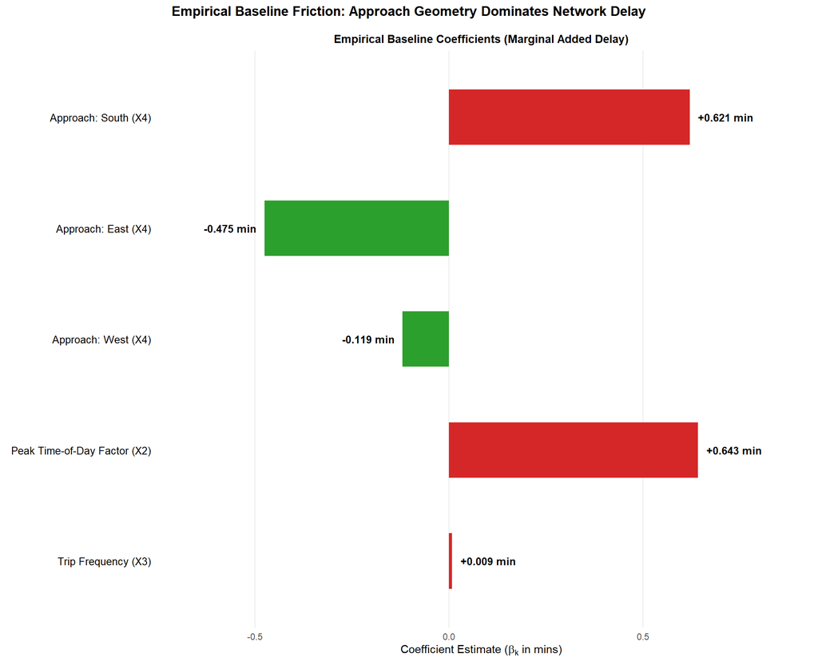

Figure 12: Full-Specification (Model 3) Marginal Delay Coefficients ($\beta_k$) by Operational Predictor and Approach Corridor.

### 5.1.2 Application of Machine Learning Techniques

While the hierarchical regression models in Section 5.1.1 establish formal statistical significance and linear coefficient estimates, relying solely on linear regression assumes that operational factors affect travel delay in a strictly additive manner. To test whether non-linear variable interactions exist and to evaluate how accurately our model predicts delays on unseen bus trips, we apply machine learning algorithms using the `caret` package[^22]. To keep training and testing data strictly separate and see how the model handles unseen trips, the trip-level matrix is partitioned into an **80% training set** (*268,741 trips*) and an **independent 20% test set** (*67,183 trips*). This split is stratified by route and time-of-day status to ensure both sets maintain identical, representative portions of traffic conditions across all corridors.

Within the training partition, we evaluate three distinct algorithms—**Ordinary Least Squares (`lm`), Regularized Elastic Net (`glmnet`),** and a high-performance C++ **Random Forest (`ranger`)** regressor—using 5-fold cross-validation[^23]. Utilizing `method = "lm"` allows us to test standard linear regression on unseen data under identical cross-validation rules, confirming that our simple linear model generalizes well without overfitting (*memorizing random quirks in the past data rather than true patterns*). Using `method = "glmnet"` applies regularization to modify the fitting procedure, introducing penalty terms to large parameter estimates to safeguard against overfitting and multicollinearity. Finally, `method = "ranger"` acts as a non-parametric benchmark (*making no assumptions about linearity*) that combines hundreds of decision trees to capture fine-grained threshold effects and complex traffic interactions, setting a performance prediction ceiling. The machine learning evaluation script is available in `scripts/test_04_fit_caret_operational_delay.R`. For the regularized Elastic Net model, predictors were centered and scaled and evaluated across a 10-point hyper-parameter tuning grid.

```r
fit_enet <- train(
  delay_Pi_to_KP ~ .,
  data = train_set,
  method = "glmnet",
  trControl = train_ctrl,
  preProcess = c("center", "scale"),
  tuneLength = 10
)
```

#### 5.1.2.1 Model Performance Comparison

The performance comparison of the machine learning models across the 5-fold cross-validation training set and independent test set is summarized in Table 12.

Table 12: Cross-Validated Training and Holdout Test Performance Across Operational Delay Models.

| Benchmark Model Performance Model Algorithm | Benchmark Model Performance Train RMSE | Benchmark Model Performance Train R<sup>2</sup> | Benchmark Model Performance Train MAE | Benchmark Model Performance Test RMSE | Benchmark Model Performance Test R<sup>2</sup> | Benchmark Model Performance Test MAE |
| --- | --- | --- | --- | --- | --- | --- |
| Random Forest | 12.2559 | 0.0031 | 3.6751 | 11.5532 | 0.0047 | 3.6730 |
| OLS Linear Regression | 12.2525 | 0.0013 | 3.6853 | 11.5692 | 0.0020 | 3.6813 |
| Elastic Net (glmnet) | 12.2307 | 0.0013 | 3.6850 | 11.5693 | 0.0020 | 3.6809 |

On the independent test set, the OLS model achieves a Test RMSE of **11.5692 minutes**, a Test MAE of **3.6813 minutes**, and a Test $R^2$ of **0.0020**. Because the test error does not degrade relative to training—with Test RMSE slightly lower than Training RMSE (*12.2525*) and Test MAE virtually identical to Training MAE (*3.6853*)—the parametric OLS model shows no sign of overfitting and generalizes cleanly to unseen data. This also demonstrates that the parametric OLS holds up well as a tool for hypothesis testing. Notably, the wide gap between MAE (*~3.68 minutes*) and RMSE (*~11.57 minutes*) highlights the role of extreme traffic anomalies in the dataset. Because MAE weights all errors equally, it shows that predictions on a typical trip stay within 4 minutes; RMSE, by contrast, squares prediction errors to deliberately penalize the model for extreme disruption outliers, pulling the overall metric much higher. Elastic Net regularization yields performance virtually identical to OLS (*Test* *RMSE = 11.5693*), confirming that regularization provides no additional benefit and that core empirical predictors do not suffer from multicollinearity (*overlapping predictors interfering with one another*).

Crucially, applying the Random Forest algorithm yields only marginal predictive improvements (*Test RMSE = 11.5532, Test* $R^2$ *= 0.0047*). The fact that a complex, non-linear decision tree ensemble cannot significantly outperform a rigid OLS model demonstrates that the remaining unexplained variance in the dataset is largely stochastic noise caused by random daily traffic, stoplights, and weather. The 3-predictor OLS model successfully extracted all of the systematic structural friction available in the baseline dataset.

#### 5.1.2.2 Feature Importance & Non-Linear Thresholds

By withholding the deterministic spatial extension variables ($X_1$ and $X_5$) from the machine learning pipeline, the Random Forest feature importance rankings isolate the drivers of historical delay. As illustrated in Fig. 13, analyzing these rankings reveals a notable operational contrast: while the linear OLS model identified the peak time-of-day factor ($X_2$) and Southern approach geometry ($X_4$) as carrying the largest additive penalty in total minutes, the Random Forest algorithm identifies scheduled **Trip Frequency** ($X_3$) as the overwhelmingly dominant structural predictor (*Importance = 100.0*). System-wide peak time-of-day acts as a distant secondary driver (*Importance = 15.2*). Furthermore, the algorithm ranks the Eastern approach vector (*Importance = 12.5*) ahead of the Southern approach (*Importance = 6.7*), while the Western approach ranks lowest on the normalized importance scale (0.0).

This nuanced divergence between the two models highlights why both algorithms are useful in tandem for evaluating the network. OLS demonstrates that peak traffic patterns and Providence’s Southern street geometry impose a rigid, average time penalty on specific corridors. However, the non-linear Random Forest reveals that localized berth congestion and bus arrival overlap—captured by scheduled route frequency—are the primary catalysts for complex schedule degradation.

In the linear OLS model, trip frequency appeared statistically insignificant when competing against spatial geometry. In a decision tree ensemble, however, trip frequency exhibits non-linear importance: once a route’s frequency crosses a specific threshold, the constrained Downcity streets can no longer absorb the traffic, causing delay to compound non-linearly rather than additively. This establishes a critical baseline fragility: stacking any additional physical routing extensions onto these highly sensitive, frequency-constrained corridors risks triggering cascading network failures.

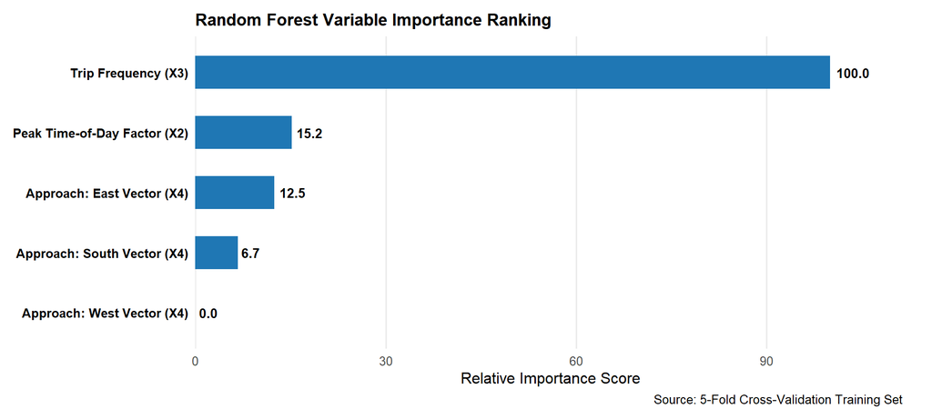

Figure 13: Random Forest Feature Importance Ranking

### 5.1.3 Deterministic Extension Projection

As demonstrated by the machine learning evaluation in Section 5.1.2, the existing downtown transit network is already highly sensitive to scheduled service frequencies and legacy approach geometries. With this baseline structural fragility established, the deterministic simulation isolates the spatial penalty of the relocated hub ($X_1 \times X_5$) and stacks it directly on top of the empirical baseline.

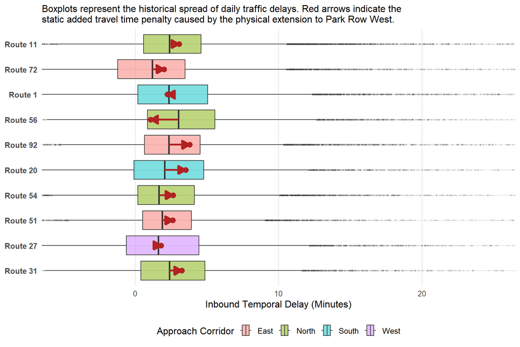

Figure 14: Top 10 High-Frequency Corridors: Empirical Baseline Delay Variance vs. Deterministic Hub Relocation Penalty

```r
library(tidyverse)
library(ggplot2)

df_raw <- read_csv("../data/ripta_kp_final_dataset.csv", show_col_types = FALSE)

# 1. Isolate the Top 10 High-Frequency Routes
top_10_routes <- df_raw |>
  group_by(route_id, approach_direction) |>
  summarize(total_trips = n(), .groups = "drop")  |>
  arrange(desc(total_trips))  |>
  slice_head(n = 10)  |>
  mutate(route_label = paste("Route", route_id))

# 2. Filter dataset and calculate deterministic penalties
plot_df <- df_raw  |>
  inner_join(top_10_routes, by = c("route_id", "approach_direction"))  |>
  mutate(
    route_label = factor(route_label, levels = rev(top_10_routes$route_label)),
    deterministic_penalty = route_ext_distance_miles * travel_time_rate_min_per_mi,
    projected_total_delay = delay_Pi_to_KP + deterministic_penalty
  )

# 3. Calculate medians for the arrows
arrow_data <- plot_df  |>
  group_by(route_label, approach_direction)  |>
  summarize(
    median_baseline = median(delay_Pi_to_KP, na.rm = TRUE),
    median_projected = median(projected_total_delay, na.rm = TRUE),
    .groups = "drop"
  )

# 4. Generate the Shifted Whisker Plot
ggplot() +
  # Baseline Empirical Variance (Boxplot)
  geom_boxplot(data = plot_df,
               aes(x = delay_Pi_to_KP, y = route_label, fill = approach_direction),
               alpha = 0.5, outlier.alpha = 0.1, outlier.size = 0.5) +

  # Deterministic Extension Penalty (Red Arrow)
  geom_segment(data = arrow_data,
               aes(x = median_baseline, xend = median_projected,
                   y = route_label, yend = route_label),
               color = "firebrick", size = 1.2,
               arrow = arrow(length = unit(0.15, "inches"), type = "closed")) +

  # End Point Marker for Projected Median
  geom_point(data = arrow_data,
             aes(x = median_projected, y = route_label),
             color = "firebrick", size = 3) +

  # Formatting and Themes
  scale_fill_manual(values = c("North" = "#7CAE00", "South" = "#00BFC4",
                               "East" = "#F8766D", "West" = "#C77CFF")) +
  coord_cartesian(xlim = c(-5, 25)) + # Zooms in to exclude extreme 100+ min anomalies for readability
  labs(
    x = "Inbound Temporal Delay (Minutes)",
    y = NULL,
    fill = "Approach Corridor",
    subtitle = "Boxplots represent the historical spread of daily traffic delays. Red arrows indicate the \nstatic added travel time penalty caused by the physical extension to Park Row West."
  ) +
  theme_minimal(base_size = 12) +
  theme(
    legend.position = "bottom",
    panel.grid.minor = element_blank(),
    axis.text.y = element_text(face = "bold")
  )
```

## 5.2 Operating Costs and Fleet Requirements Assessment

Building on the baseline operational fragility established in Section 5.1, we now simulate the physical relocation of the hub to Park Row West-Francis Street (`scripts/test_05_generate_op_costs.R`). Applying the projected temporal delay penalties $(\hat{Y}_{ext(i)})$ to RIPTA’s observed daily inbound trip volumes across the full $N=335,924$ observation window yields significant systemic cost expansions. As detailed in Table 13, relocating the transit hub to Park Row West generates a **net annual increase of 2,336 Vehicle Revenue Hours (VRH)** across the network, equating to roughly **6.4 hours** of added driving time per day.

Table 13: Systemwide Operational, Financial, and Fleet Impacts of Relocating the Transit Hub to Park Row West.

| Systemwide Impact Summary Metric | Systemwide Impact Summary Value |
| --- | --- |
| Evaluated Daily Inbound Runs (N) | 920 |
| Net Systemwide Mean One-Way Trip Delay (including Northern shortcuts) | 0.21 mins |
| Mean Physical Extension Distance | 0.059 miles |
| Daily Added Vehicle Revenue Hours (VRH) | 6.4 hrs/day |
| Annual Added Vehicle Revenue Hours (VRH) | 2,336 hrs/year |
| Annual Marginal Operating Cost Increase | $394,279 |
| Additional Peak Fleet Units Required (VOMS) | +2 buses |

Applying RIPTA’s system-wide operating cost of $168.77 per revenue hour, this physical extension imposes a **net annual marginal operating cost of** **$394,279**. It is critical to note that this is a net figure that masks the severity of specific corridor penalties. Because certain routes arriving from the North (*most notably Routes 56, 50, 57, and 55*) truncate prior to entering the deep Downcity core, they experience negative delays that mathematically yield an aggregate operational savings. However, these localized savings are entirely consumed and overwhelmed by the spatial penalties imposed on the rest of the network, driving the mean one-way trip delay up by 0.21 minutes (*an average physical extension of 0.059 miles*).

Furthermore, because these delays compound non-linearly across frequency-constrained corridors during rush hour, absorbing this penalty without degrading existing service schedules will require RIPTA to inject an estimated **2 additional peak fleet units (Vehicles Operated in Maximum Service, VOMS)** on a net system-wide basis. That 2-bus estimate assumes RIPTA can take the minutes saved on shorter routes and redistribute the savings directly towards other routes. In practice, if Northern lines cannot free up additional resources, the slowed corridors alone would need up to **3 extra buses**. As illustrated in Fig. 15, the diverging cost impacts confirm that a universal relocation strategy forces severe operational deficits onto Eastern, Southern, and Western routes—led by Route 92 (East), Route 20 (South), and Route 72 (East).

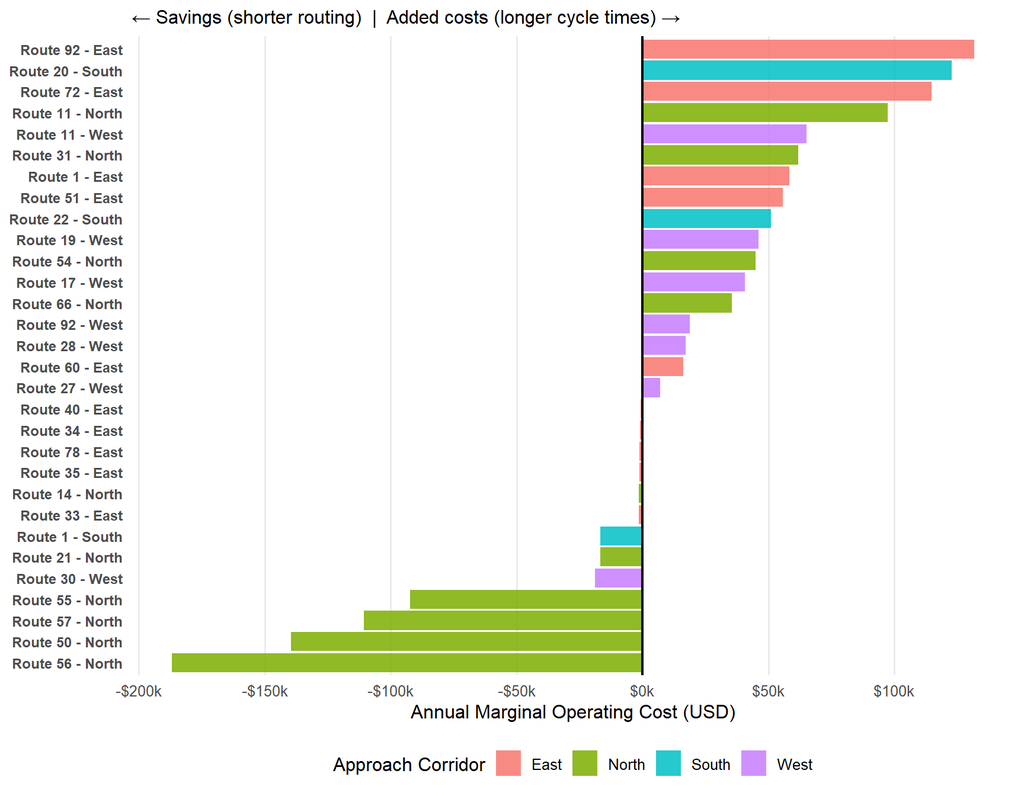

Figure 15: Projected Annual Marginal Operating Cost Impacts by Route and Approach Corridor (Park Row West Relocation).

## 5.3 Equity & Rider Accessibility Impacts

While the preceding section quantified the agency-side financial and fleet burdens of relocating the hub to Park Row West, those operational metrics do not capture the human cost borne by passengers. To evaluate how the 1,820-foot spatial gap affects daily commuters and transit-dependent communities, we simulate passenger-level mobility and equity outcomes (`scripts/test_06_equity_pedestrian_impact_sim.R`).

### 5.3.1 Simulated Rider Displacement

Executing the Monte Carlo simulation across 1,000 iterations per historical bi-directional trip estimates the volume of displaced riders generated by the proposed relocation. By applying the stochastic hub apportionment ratio $(H \sim U(0.30,0.50))$ and the displaced rider rate $(D \sim U(0.490, 0.641))$ to the empirical trip baselines, the model isolates the cohort of passengers who must actively bridge the 1,820-foot spatial gap between Kennedy Plaza and the proposed Park Row West terminal.

### 5.3.2 Modal Split & Time-to-Board Degradation

The extra 0.34-mile distance forces most displaced passengers onto a connector shuttle rather than walking, introducing steep wait-time penalties. Even for able-bodied commuters, a third-of-a-mile uphill transfer exceeds typical walking tolerance, pushing the majority into the R-Line shuttle queue. For mobility-challenged riders, the uphill grade makes walking virtually unfeasible, leaving them entirely dependent on the shuttle. Instead of a seamless downtown transfer, riders absorb **both shuttle wait times and added travel time** before reaching their connecting bus. On inbound trips back toward Downcity, however, the simulation accounts for the 13.8% downhill walking speed advantage, reflecting a higher propensity to walk when the terrain is favorable.

### 5.3.3 Statistical Evaluation of Equity Impacts

To determine whether the accessibility degradation and routing burdens imposed by the hub relocation constitute a disparate impact under federal civil rights guidelines, a three-tiered statistical evaluation was executed across the 51 evaluated route-directions.

- **Test A1 (System-Wide Rider Penalty):** Before testing for demographic disparities, a one-sample $t$-test evaluated whether the relocation inherently degrades network utility for displaced riders overall. Tested against a null baseline of 0 minutes (*representing the current direct ride to and from Kennedy Plaza*), the network-wide mean pedestrian penalty of **+13.37** minutes is highly statistically significant $(t=51.7170, p<0.0001)$ (*see Table 14*). This formally establishes that the 1,820-foot gap and resulting transfer disconnect impose a severe adverse effect on displaced Downcity passengers.

Table 14: Test A1: One-Sample t-Test (System-Wide Rider Penalty)

| Test A1: System-Wide Rider Penalty Summary Metric | Test A1: System-Wide Rider Penalty Summary Evaluation Outcome |
| --- | --- |
| Network-Wide Sample Size (N Routes) | 51 |
| Baseline KP Penalty ($\mu_0$) | 0.00 mins |
| Simulated Park Row West Mean Penalty | 13.37 mins |
| Mean Systemic Degradation | +13.37 mins |
| t-statistic | 51.7170 |
| p-value | < 0.0001 |
| Statistical Conclusion | Reject $H_0$ (Statistically Significant Harm) |

- **Test B1 (Transfer Delay by Demographic):** Following the establishment of system-wide harm, a one-sided two-sample $t$-test evaluated whether vulnerable corridors absorb a disproportionately larger share of this delay. Vulnerable routes experienced an average penalty of **13.69 minutes**, compared to **12.94 minutes** for non-vulnerable routes. While the vulnerable cohort experienced a slightly longer average delay (*+0.75 minutes*), the test yielded a $t$-statistic of 1.4055 and a $p$-value of 0.0838 (Table 15). Because this $p$-value exceeds the standard 0.05 threshold, the physical walk and R-Line shuttle operate as a near-universal penalty that degrades service across all displaced riders, though the directional gap approaches marginal significance $(\alpha=0.10)$.

Table 15: Test B1: Two-Sample t-Test (Rider Transfer Delay by Equity Cohort)

| Test B1: Rider Transfer Penalty by Equity Cohort Metric | Test B1: Rider Transfer Penalty by Equity Cohort Vulnerable Cohort | Test B1: Rider Transfer Penalty by Equity Cohort Non-Vulnerable Cohort |
| --- | --- | --- |
| Sample Size (N Routes) | 29 | 22 |
| Mean Temporal Penalty | 13.69 mins | 12.94 mins |
| Mean Difference | +0.75 mins | - |
| t-statistic | 1.4055 | - |
| p-value | 0.0838 | - |
| Statistical Conclusion | Fail to Reject $H_0$ (Universal Penalty Across Cohorts) | - |

- **Test B2 (Equity Status vs. Operational Burden):** Finally, a Chi-Square test of independence $(\chi^2)$ evaluated whether routes facing operational extension penalties $(\hat{Y}_{ext}>0)$ are disproportionately classified as vulnerable corridors (Table 16).

Table 16: Test B2: Chi-Square Test of Independence (Operational Burden by Equity Cohort)

| Test B2: Route Operational Burden by Equity Cohort Equity Status | Test B2: Route Operational Burden by Equity Cohort Severe Burden ($\hat{Y}_{ext} > 0$) | Test B2: Route Operational Burden by Equity Cohort Truncated/Relief ($\hat{Y}_{ext} \le 0$) | Test B2: Route Operational Burden by Equity Cohort Total Routes |
| --- | --- | --- | --- |
| Non-Vulnerable | 11 | 11 | 22 |
| Vulnerable | 19 | 10 | 29 |
| Total | 30 | 21 | 51 |

The test yielded $\chi^2$ = 0.6855, $p$ = 0.4077. Because the $p$-value exceeds the 0.05 threshold, there is no statistically significant association between a route’s equity classification and its operational burden at the 95% confidence level. While vulnerable corridors account for 63% of all severely burdened route-directions (*19 of 30*), they also capture nearly half of the truncated relief routes (*10 of 21, primarily approaching from the North*). Rather than isolating a single demographic group, the relocation creates a geographic divide—concentrating operational relief on select Northern routes while imposing compounding delays across Southern, Eastern, and Western corridors regardless of equity classification.

## 5.4 Summary of Findings

Taken together, the empirical results in this section point to a consistent conclusion across operational, financial, and passenger dimensions. The machine learning delay model in Section 5.1.2 demonstrates that RIPTA’s Kennedy Plaza network already operates with structural fragility during peak periods, capturing how physical extension distance, approach corridor, and rush-hour congestion interact non-linearly to drive route-level temporal penalties $(\hat{Y}_{ext})$. Feeding those model-predicted delays into the network cost simulation shows that relocating the hub to Park Row West compounds that strain—adding **2,336 annual VRH**, **$394,279 in net annual operating costs**, and **2 to 3 additional peak buses** depending on scheduling flexibility. For riders, the relocation imposes a statistically significant +13.37-minute average transfer penalty across the network. Although demographic disparities in delay duration $(p=0.0838)$ and route burden ($p$ = 0.4077) do not cross the 0.05 threshold for statistical significance, vulnerable routes still absorb the majority of extended corridors (*19 of 30*) and experience a slightly higher mean penalty. Next, we synthesize these findings into policy implications, consider mitigation alternatives, and outline concrete recommendations for Providence’s transit hub planning.

# 6 Conclusion / Recommendations

Building on the empirical results in Section 5, this section formally resolves the study’s core research questions and translates the predictive, financial, and accessibility findings into actionable transit policy recommendations for RIPTA and the City of Providence.

## 6.1 Operational Delay Model: Conclusions & Recommendations

### 6.1.1 Formal Hypothesis Testing & Resolution of Key Question I

To resolve **Key Question I** (*What causes bus delays in downtown Providence today, and how will extending routes to Park Row West affect on-time reliability and operating costs?*), we evaluate the Full Specification OLS Linear Model (**Model 3**).

The formal statistical hypothesis test is defined as:

- **Null Hypothesis** $(H_0: \beta_2=\beta_3=\beta_4 = 0)$: Baseline operational friction is uniform; peak traffic, service frequency, and approach direction do not structurally compound schedule delays.
- **Alternative Hypothesis** $(H_a: \textbf{At least one } \beta_k \ne 0 \textbf{ for }k \in \{2,3,4\})$: Operational factors and legacy street geometries drive statistically significant schedule delays.

Model 3 establishes a baseline intercept of **+2.69 minutes** per inbound trip. Sequential ANOVA confirms that approach geometry $(X_4;F=77.69, p < 0.0001)$ and peak-hour traffic ($X_2;$ *+0.64 minutes*) add **highly significant explanatory power** $(p < 0.001)$, whereas scheduled frequency $(X_3)$ is not statistically significant as a linear predictor in the full specification. Notably, the Southern approach vector imposes the largest baseline geometric penalty (*+0.62 minutes*), before any hub extension is simulated. Accordingly, we *reject* **the null hypothesis** $(H_0)$ **in favor of** $H_a$.

**Conclusion for Key Question I:** Relocating the hub to Park Row West adds fixed extension delays onto corridors already operating near capacity. While select Northern routes gain marginal relief from shorter paths, Eastern, Southern, and Western routes absorb compounding delays that directly expand vehicle revenue hours, fleet requirements, and operating costs.

### 6.1.2 Machine Learning Insights for Service Optimization

Benchmarking OLS against Elastic Net (`glmnet`) and Random Forest (`ranger`) on the 20% holdout set (*67,183* *unseen trips*) yields two operational takeaways:

1. **Reliable Schedule Calibration:** OLS maintains consistent accuracy on the holdout set (*Test* $R^2$ *= 0.0020, RMSE = 11.57 min, MAE = 3.68* *min*), providing schedulers with **predicted trip delays** $(\hat{Y}_{i,t})$ as a transparent, data-driven baseline for building realistic schedule buffers (‘*timetable padding*’).
2. **Frequency as the Network Tipping Point:** While OLS highlights peak $(X_2)$ timing and Southern $(X_4)$ geometry as top additive penalties, Random Forest isolates Trip Frequency $(X_3)$ as the dominant non-linear driver (*100% normalized importance*). When too many buses pack onto the same corridor, local backups cause rush-hour route-extension delays to spike sharply.

### 6.1.3 Actionable Optimization Recommendations

- **Deploy Peak-Hour Transit Signal Priority (TSP):** Rather than costly roadway widenings, RIPTA should implement Transit Signal Priority (TSP) and peak-period bus lanes along Memorial Boulevard and Francis Street to directly counter the peak-hour multiplier $(X_2)$.
- **Redesign Southern & Eastern Approach Alignments:** Evaluate direct transit-only bypasses or split-terminal alignments for high-frequency Southern and Eastern lines (*e.g., Routes 1, 20, 22, 72, 92*) to eliminate circuitous Downcity looping before reaching Park Row West.

## 6.2 Operating Costs & Fleet Requirements: Conclusions & Recommendations

### 6.2.1 Formal Conclusion of Financial Impacts

Relocating the hub to Park Row West imposes a **net annual operating cost increase of** $394,279 (*2,336 additional annual VRH*) and requires 2 additional peak buses (*VOMS*) on a net system-wide basis—rising to 3 additional buses if shortened Northern routes cannot directly transition resources saved to the other routes. While RIPTA navigates an ongoing fiscal cliff, spending nearly $400,000 annually and committing 2 to 3 peak vehicles solely to absorb physical routing extensions yields zero improvement in service frequency or rider coverage.

### 6.2.2 Actionable Optimization Recommendations

- **Adopt a Split-Hub or Cross-Town Strategy:** Terminating Northern routes (*e.g., Routes 50, 55, 56, 57*) at Park Row West generates genuine time and cost savings, but forcing the rest of the network to follow creates a steep financial deficit. Rather than a universal relocation, RIPTA should terminate Northern lines at Park Row West, while keeping Eastern, Southern, and Western lines anchored at Kennedy Plaza or paired into continuous cross-town routes (*e.g., Routes 1, 92*)—capturing Northern efficiencies without penalizing the rest of the system.

## 6.3 Equity & Rider Accessibility Impacts: Conclusions & Recommendations

### 6.3.1 Formal Hypothesis Testing & Resolution of Key Question II

To resolve **Key Question II** (*Does moving the hub away from Kennedy Plaza create an inequitable burden (‘disparate impact’) that hits low-income, senior, and mobility-challenged riders hardest?),* we evaluate three formal hypotheses across 51 evaluated route-directions:

- **Test A1 (System-Wide Rider Penalty - One-Sample** $t$**-test):** $H_0: \mu \leq 0$ vs. $H_a: \mu > 0$.
- **Test B1 (Transfer Delay by Equity Cohort - Two-Sample** $t$**-test):** $H_0: \mu_{\text{vulnerable}} \leq \mu_{\text{non-vulnerable}}$ vs. $H_a: \mu_{\text{vulnerable}} > \mu_{\text{non-vulnerable}}$.
- **Test B2 (Equity Status vs. Operational Burden - Chi-Square Test):** $H_0$: Route operational burden and equity status are independent vs. $H_a$: Operational burden is dependent on equity status.

### 6.3.2 Statistical Resolution

**Test A1:** The network-wide mean transfer penalty of **+13.37 minutes** $(t=51.7170, p<0.0001)$ is highly significant. We **reject** $H_0$, confirming the severe system-wide harm to all displaced Downcity riders.

**Test B1:** Vulnerable corridors average **13.69 minutes** of delay versus **12.94 minutes** for non-vulnerable corridors (*+0.75 min;* $t=1.4055, p=0.0838$). Because $p>0.05$, we **fail to reject** $H_0$—the walk/shuttle barrier penalizes displaced riders broadly across demographics, though the gap approaches marginal significance $(\alpha=0.10)$.

**Test B2:** The Chi-Square test yields $\chi^2=$ 0.6855, $p =$ 0.4077. Because $p>0.05$, we **fail to reject** $H_0$. While vulnerable corridors account for **63.3%** of severely burdened routes (*19 of 30*), they also comprise nearly half of the truncated relief routes (*10 of 21, largely from the North*).

**Conclusion for Key Question II:** The Park Row West relocation does not produce a statistically significant demographic disparate impact at the 95% confidence level because the layout creates a **geographic divide** rather than a purely demographic one. However, it inflicts a statistically undeniable **+13.4-minute penalty** across all displaced riders. In practice, this uniform degradation still disproportionately harms transit-dependent, elderly, and mobility-challenged riders who cannot easily shift to private vehicles or walk the 1,820-foot uphill grade.

### 6.3.4 Actionable Equity & Accessibility Recommendations

- **Preserve Zero-Transfer Access for Vulnerable Corridors:** Maintain direct Downcity boarding at Kennedy Plaza (*via split-hub or cross-town route design*) for high-vulnerability Southern, Eastern, and Western routes to eliminate the 1,820-foot uphill transfer for seniors and mobility-challenged riders.
- **Guarantee High-Frequency, Accessible Shuttle Service:** If Park Row West proceeds, mandate a dedicated, zero-fare shuttle running every 5 minutes or less during both peak and off-peak hours—coupled with sheltered, level-boarding stops—to compress the simulated +13.4-minute transfer penalty.

## 6.4 Limitations & Future Work

While this study successfully isolated the structural travel delays and rider displacement penalties caused by the Park Row West hub relocation, evaluating the downstream disruption to transit schedule synchronization remains an area for future research. Originally considered for this project, quantifying exactly how the hub relocation disrupts established bus-to-bus transfer volumes and schedule overlaps was deferred due to data limitations and project time constraints.

Without exact data tracking where passengers start, transfer, and end their trips, evaluating how well bus schedules sync up relies heavily on statistical estimates and assumptions. Relying too much on these estimates can hide the true vulnerabilities of the network. To validate the findings of this project and advance transit equity analysis, RIPTA should consider the following operational data initiatives:

- **Implementation of Automated Passenger Counters (APC):** RIPTA should prioritize outfitting its fleet with APC technology to capture accurate, stop-level boarding and alighting volumes. APC data would eliminate the need for estimated hub transfer ratios and allow transit planners to empirically calculate the exact volume of transfer riders vs. final-destination riders at any terminal.
- **Live Route Validation Studies:** Prior to finalizing the Park Row West relocation, the route-extension delays modeled in this report should be validated against physical pilot runs. Deploying test buses along the proposed Eastern, Southern, and Western routes during peak periods would generate real-world tracking data, offering physical proof of the severe, compounding delays predicted by our models.

## 6.5 Closing Remarks

The relocation of Providence’s central transit hub is not merely a physical infrastructure project; it is a structural transformation that taxes the system’s most fragile corridors and places the heaviest practical burden on vulnerable riders. The data science models deployed in this study demonstrate that a universal, one-size-fits-all relocation to Park Row West is mathematically incompatible with the city’s asymmetrical street grid. By forcing the entire network to navigate the northern periphery, the agency will incur nearly $400,000 in net annual operating costs—and require 2 to 3 additional peak buses—while subjecting displaced Downcity riders to a severe 13.4-minute systemic transfer penalty. Crucially, this burden is not shared equally. The spatial geometry of the new hub dictates a stark geographic divide, offering operational relief to Northern corridors while relegating Eastern, Southern, and Western corridors—and the transit-dependent riders who rely on them—to trips with compounding delays. This structural divide actively undermines the Transit Forward RI 2040 Master Plan’s core mandate to expand high-frequency transit for low-income and minority residents. To prevent these cascading schedule failures and ensure equitable transit access, RIPTA should evaluate alternatives to the single-hub paradigm. By implementing targeted split-hub and cross-town routing, deploying Transit Signal Priority (TSP) corridors, and ensuring frequent, accessible Downcity shuttle service, the agency can modernize its infrastructure without sacrificing the reliability and accessibility that its most vulnerable riders depend on.

# 7 Data & Code Availability

The processed datasets generated and analyzed during this project, along with the complete R processing scripts, are available in the project repository at https://github.com/lmannings-jklm/capstone-ripta-plan. All third-party spatial and demographic inputs can be retrieved directly from their respective public portals.

# 8 Acknowledgements

Special thanks go out to the HarvardX Data Science program for providing the foundation and motivation to select and complete this project. Additional thanks go to my family and several professional colleagues who encouraged me to focus on a problem with meaningful impacts on my community. I gratefully acknowledge RIPTA Legal Services and agency data administrators for fulfilling this public records request and providing access to historical Computer-Aided Dispatch and Automatic Vehicle Location (CAD/AVL) archives.

## 8.1 Disclosure of Artificial Intelligence Usage

During the preparation of this work, the author utilized Google Gemini resources (*specifically NotebookLM and Gemini 3.1 Pro*) to assist with preliminary research, language editing, citation formatting, analytical brainstorming, and code review/troubleshooting. All AI-generated outputs, analyses, and code suggestions were critically reviewed, verified, and edited by the author. Every reference cited has been reviewed for appropriateness and independently verified against the primary sources.

# 9 Data Attribution & Disclaimer

## 9.1 Data Attribution

The empirical analyses presented in this report utilize operational transit data provided by the Rhode Island Public Transit Authority (RIPTA) pursuant to a formal public records request under the Rhode Island Access to Public Records Act, supplemented by public General Transit Feed Specification (GTFS) and GTFS-Realtime feeds published by the agency. Demographic, elevation, and street-network inputs are sourced from the U.S. Census Bureau American Community Survey (ACS), the Rhode Island Geographic Information System (RIGIS), and OpenStreetMap.

## 9.2 Disclaimer of Affiliation and Views

This report, including all underlying analytical models, statistical interpretations, geospatial evaluations, visualizations, findings, and recommendations, is the independent academic work product of the author. This report does not contain or reflect the official views, policies, opinions, endorsements, or work product of RIPTA, the State of Rhode Island, or any of their respective agencies or affiliates.

All analyses, models, and conclusions presented herein are solely based on the empirical data and public documentation provided by or obtained from RIPTA, evaluated independently by the author. RIPTA assumes no responsibility or liability for any errors, omissions, interpretations, conclusions, or downstream applications derived from the data used in this study.

# Glossary

**Automatic Passenger Counter (APC):** An automated system for counting passengers as they board or alight transit vehicles using treadle mats, infrared beams, or other devices placed at vehicle doors.

**GeoPackage:** An open, non-proprietary, platform-independent container format for storing spatial vector data, raster images, and non-spatial attribute tables. Maintained by the Open Geospatial Consortium, it is a modern industry standard for geospatial data exchange.

**Isochrone:** A polygon on a map illustrating the geographic area reachable from a fixed starting point within a specified travel time.

**Primary Transit Corridor:** A high-frequency urban transit route operating along a major arterial roadway with peak headways of 30 minutes or less, serving as a primary spine connecting regional passenger flows to the central transit hub.

**Service Frequency:** A transit service metric representing the number of transit vehicles serving the same route and direction within a given period of time (*e.g., 4 vehicles per hour*). It is the mathematical inverse of **Trip Headway**.

**Transit Signal Priority (TSP):** An operational strategy that adjusts traffic signal timing at intersections to give priority to transit vehicles operating in median busways, exclusive bus lanes, or mixed traffic, while maintaining signal coordination and overall cycle length along a corridor.

**Trip Headway:** The elapsed time between two consecutive transit vehicles operating along the same route and direction (*e.g., if the RIPTA Route 1 bus arrives at Kennedy Plaza at 8:00 AM and the next arrives at 8:15 AM, the trip headway is **15 minutes***).

**Unlinked Passenger Trip (UPT):** A transit ridership metric in which every individual boarding of a transit vehicle is counted as a separate trip. For example, if a passenger rides Route 1 and transfers to Route 60, the database records two separate boardings rather than a single linked journey.

**Vehicle Revenue Hours (VRH):** The hours that transit vehicles travel while in active revenue service. This includes running time, layover/recovery time, and passenger loading time, but explicitly excludes “deadhead” time (*traveling to and from the dispatch garage with doors closed*), operator training, charter services, and vehicle maintenance testing (*Reference: National Transit Database (NTD) Glossary*).

**Vehicles Operated in Maximum Service (VOMS):** The largest number of vehicles operated at peak service during the busiest average day of any year. VOMS does not include spare vehicles and is typically smaller than the total fleet size (*Reference: Federal Transit Administration, “General NTD Reporting - Frequently Asked Questions”*).

**Walkshed:** A pedestrian catchment map representing the geographic area reachable on foot from a fixed starting point, commonly used in urban planning and transportation analysis to evaluate pedestrian infrastructure.

**World Geodetic System 1984 (WGS 84):** A standard, earth-centered terrestrial reference frame and geodetic coordinate system established by the U.S. Department of Defense. In spatial data science and public transit specifications, WGS 84 serves as the universal coordinate system for GPS tracking and defines the latitude and longitude coordinates used across General Transit Feed Specification (GTFS) datasets.

# Technical Appendix

## GTFS Feed & Schema Summary

The GTFS requires several text files to sufficiently describe a transit network. Most of the files were modified to reflect the relocation of transit hubs. A brief description of each is as follows:

- `stops.txt`: Lists all transit stops in the network, providing a unique stop ID along with latitude and longitude coordinates based on the WGS 84 datum.
- `routes.txt`: Defines all transit lines, specifying a unique route ID, short name, and basic route metadata.
- `trips.txt`: Logs every individual trip across the network, linking trip IDs to their corresponding route IDs.
- `route_timepoints.txt`: A custom file generated by RIPTA to designate which stops act as official published timetable timepoints for a given route.
- `stop_times.txt`: Contains detailed scheduling information, recording the exact scheduled arrival and departure times for each trip at every associated stop ID.
- `shapes.txt`: Describes the path that a vehicle travels along a route. Shapes are associated with trips and consist of a sequence of points through which the vehicle passes in order.
- `calendar.txt` and `frequencies.txt`: Define service calendars, trip headways, and service duration.

## Core R Packages & Analytical Environment

The following core R packages were used in this study:

**`tidyverse`:** Popular collection of R packages designed for data manipulation and visualization.

**`sf`:** Modern standard for handling, manipulating, and visualizing spatial vector data in R.

**`tidytransit`:** Reads, validates, analyzes, and maps public transit data stored in the GTFS format.

**`terra`:** Ingests and processes Digital Elevation Model (DEM) raster grids for the Providence area.

**`tidycensus`:** Pulls U.S. Census Bureau boundary and demographic data directly into R via API.

**`osrm`:** Computes street-network paths, travel distances, travel times, and walking accessibility polygons.

**`caret`:** Comprehensive framework for cross-validated machine learning and statistical modeling in R.

## Footnotes

[^1]: Rhode Island Public Transit Authority (RIPTA), *Providence Transit Center Joint Development Project Task 2, Part I – Site Evaluations & Commercial Feasibility* (2025), 1–2.
[^2]: Randall Rose, “Moving Kennedy Plaza Bus Hub Will Inconvenience RIPTA Riders and Interfere with Climate Goals,” ecoRI News, March 13, 2024, https://ecori.org/moving-kennedy-plaza-will-inconvenience-ripta-riders-and-interfere-with-climate-goals/; Steve Ahlquist, “*Despite Rider Opposition, RIPTA Board Votes to Move the Bus Hub out of Kennedy Plaza*,” RINewsToday, August 28, 2026, https://rinewstoday.com/despite-rider-opposition-ripta-board-votes-to-move-the-bus-hub-out-of-kennedy-plaza-steve-ahlquist/; Providence City Council, Resolution No. 237, passed May 16, 2024, effective May 26, 2024; Rhode Island General Assembly, House, An Act Relating to Public Utilities and Carriers – Rhode Island Public Transit Authority, H 7464, 2026 Sess., introduced January 30, 2026; Rhode Island General Assembly, Senate, An Act Relating to Public Utilities and Carriers – Rhode Island Public Transit Authority, S 2680, 2026 Sess., introduced February 27, 2026.
[^3]: Rhode Island Public Transit Authority, *Transit Forward RI 2040* (Providence, RI), https://www.ripta.com/sites/default/files/2025-10/TFRI-Recs-Briefing-Book-Final-201230.pdf.
[^4]: *MobilityData, “Overview,” General Transit Feed Specification (GTFS) Technical Documentation, accessed September 11, 2026, https://gtfs.org/documentation/overview/.*
[^5]: Chelsey Palmateer et al., “The Synergistic Effects of Transit Oriented Development and Transit Hubs on Accessibility in the San Francisco Bay Area” (working paper, University of Minnesota, August, 2, 2016), https://hdl.handle.net/11299/181535.
[^6]: Next Wave Rhode Island Partners, *Providence Transit Center Joint Development Project: Task 2, Part I – Site Evaluations & Commercial Feasibility*, report submitted to the Rhode Island Public Transit Authority (March 28, 2025), sec. 2.4, pp. 24–34; and Appendix 1C, pp. 1C-1–1C-20.
[^7]: Access to Public Records Act, R.I. Gen. Laws § 38-2-1 et seq.
[^8]: National Academies of Sciences, Engineering, and Medicine, *Transit Capacity and Quality of Service Manual*, 3rd ed., Transit Cooperative Research Program (TCRP) Report 165 (Washington, DC: The National Academies Press, 2013), https://doi.org/10.17226/24766.
[^9]: Federal Highway Administration, *A Guide for Maintaining Pedestrian Facilities for Enhanced Safety*, Report No. FHWA-SA-13-037 (Washington, DC: U.S. Department of Transportation, 2013), https://safety.fhwa.dot.gov/ped_bike/tools_solve/fhwasa13037/.
[^10]: Waldo Tobler, *Three Presentations on Geographical Analysis and Modeling: Non-Isotropic Modeling, Speculations on the Geometry of Geography, Global Spatial Analysis*, Technical Report 93-1, (Santa Barbara: National Center for Geographic Information and Analysis, University of California, 1993).
[^11]: “Providence County, RI,” Census Reporter, accessed September 21, 2026, https://censusreporter.org/profiles/05000US44007-providence-county-ri/.
[^12]: Rhode Island Geographic Information System (RIGIS). “Municipalities (1997)”. Geospatial dataset. Environmental Data Center, University of Rhode Island and Rhode Island Division of Statewide Planning. Accessed September 21, 2026. https://www.rigis.org/datasets/edc::municipalities-1997/about
[^13]: *National Academies of Sciences, Engineering, and Medicine*, Transit Capacity and Quality of Service Manual, 3rd ed., Transit Cooperative Research Program (TCRP) Report 165 (Washington, DC: The National Academies Press, 2013), pg. 4-3; pg. 3-18, https://doi.org/10.17226/24766.
[^14]: Rhode Island Public Transit Authority, *Transit Forward RI 2040* (Providence, RI), Preface, ii, https://www.ripta.com/sites/default/files/2025-10/TFRI-Recs-Briefing-Book-Final-201230.pdf.
[^15]: 49 U.S.C. § 5335(a)–(b) (National Transit Database), originating from Section 15 of the Federal Transit Act (Pub. L. 93–503), as amended. Codified and published in the *United States Code*, Title 49, Subtitle III, Chapter 53, Section 5335.
[^16]: Federal Transit Administration (FTA), *National Transit Database Sampling and Estimation Manual* (Washington, DC: U.S. Department of Transportation, Federal Transit Administration), accessed via https://www.transit.dot.gov/ntd/manuals.
[^17]: Next Wave Rhode Island Partners, *Providence Transit Center Joint Development Project: Task 2, Part I – Site Evaluations & Commercial Feasibility*, report submitted to the Rhode Island Public Transit Authority (March 28, 2025), sec. 2.4, pp. 24–34, and Appendix 1C, pp. 1C-1–1C-20.
[^18]: Southwest Ohio Regional Transit Authority (SORTA / Metro) and Alfred Benesch & Company, *Government Square Transit Center Relocation Study* (Cincinnati, OH: SORTA/Metro, January 2025), https://www.go-metro.com/wp-content/uploads/2026/02/Government-Square-Relocation-Report-02052025.pdf.
[^19]: Federal Transit Administration. (2025). *2025 National Transit Summaries and Trends*. U.S. Department of Transportation.
[^20]: Transportation Research Board, *Transit Capacity and Quality of Service Manual, 2nd Edition*, TCRP Report 100 (Washington, DC: Transportation Research Board, 2003), 1-16.
[^21]: Transportation Research Board, *Transit Capacity and Quality of Service Manual, 3rd Edition*, TCRP Report 165 (Washington, DC: Transportation Research Board, 2013), 4-18.
[^22]: Max Kuhn, “The caret Package,” accessed October 12, 2026, https://topepo.github.io/caret/index.html.
[^23]: Rafael A. Irizarry, “Cross-validation,” in *Introduction to Data Science*, accessed October 12, 2026, https://rafalab.dfci.harvard.edu/dsbook-part-2/ml/resampling-methods.html#cross-validation.